# Analyses of GSE171655

## Volcano Plot with Gene Lenght

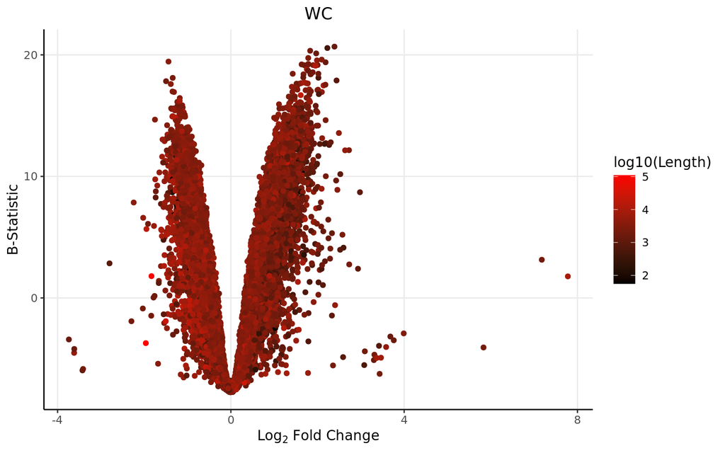

```r
DEGenes_SGS.vs.SGT$Gene <- row.names(DEGenes_SGS.vs.SGT)
colnames(genelength) <- c("Length","Gene")
DEGenes_SGS.vs.SGT <- merge(DEGenes_SGS.vs.SGT, genelength, by="Gene")

ggplot(data=DEGenes_SGS.vs.SGT,
                 aes(x=logFC,
                     y=  B)) +
  geom_point(aes(color=log10(Length)))+
  theme_bw() +
  theme(axis.line = element_line(colour = "black"),
        panel.grid.minor = element_blank(),
        panel.border = element_blank(),
        panel.background = element_blank()) +
  ggtitle("WC")+ xlab(expression(Log[2] ~ Fold ~ Change)) + ylab("B-Statistic") +
  theme(plot.title = element_text(hjust = 0.5))  +
  scale_colour_gradient(low = "black", high = "red")+ theme(text=element_text(family = "Quicksand"))
```

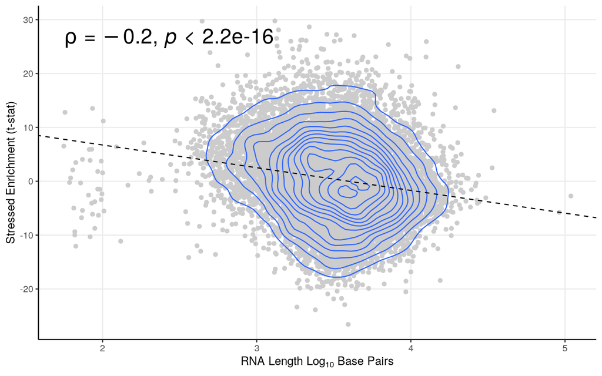

```r
smooth.SG <- lm(t~log10(Length), DEGenes_SGS.vs.SGT)
liner.SG <- rstandard(smooth.SG)
DEGenes_SGS.vs.SGT <-cbind(DEGenes_SGS.vs.SGT, liner.SG)
colnames(DEGenes_SGS.vs.SGT)[9] <- "Residuals"
row.names(DEGenes_SGS.vs.SGT) <- DEGenes_SGS.vs.SGT$Gene
linemarkers <- as.data.frame(DEGenes_SGS.vs.SGT[abs(DEGenes_SGS.vs.SGT$Residuals)>4,])

# Calculate the Spearman correlation coefficient
spearman_corr <- cor(DEGenes_SGS.vs.SGT$t, log10(DEGenes_SGS.vs.SGT$Length), method = "pearson")



ggplot(DEGenes_SGS.vs.SGT, aes(y=t, x=log10(Length))) + geom_point(color="#CCCCCC", alpha=1) +   theme_bw()+ geom_density_2d()+
 ylab("Stressed Enrichment (t-stat)") + xlab(expression(RNA ~ Length ~ Log[10] ~ Base ~ Pairs)) +
  theme(axis.line = element_line(colour = "black"),
        panel.grid.minor = element_blank(),
        panel.border = element_blank(),
        panel.background = element_blank()) +
  theme(plot.title = element_text(hjust = 0.5))  +
  geom_abline(slope=smooth.SG$coefficients[2], intercept = smooth.SG$coefficients[1], linetype = "dashed")+ stat_cor(method = "spearman", cor.coef.name = "rho",size=7)
```

Stressed SGs are smaller than their unstressed counterparts.

## Expression Graphs (Extra QC)

As an added control, lets plot these genes in regard to their expression. This helps to see if the expression differences are robust, and not just driven by one sample.

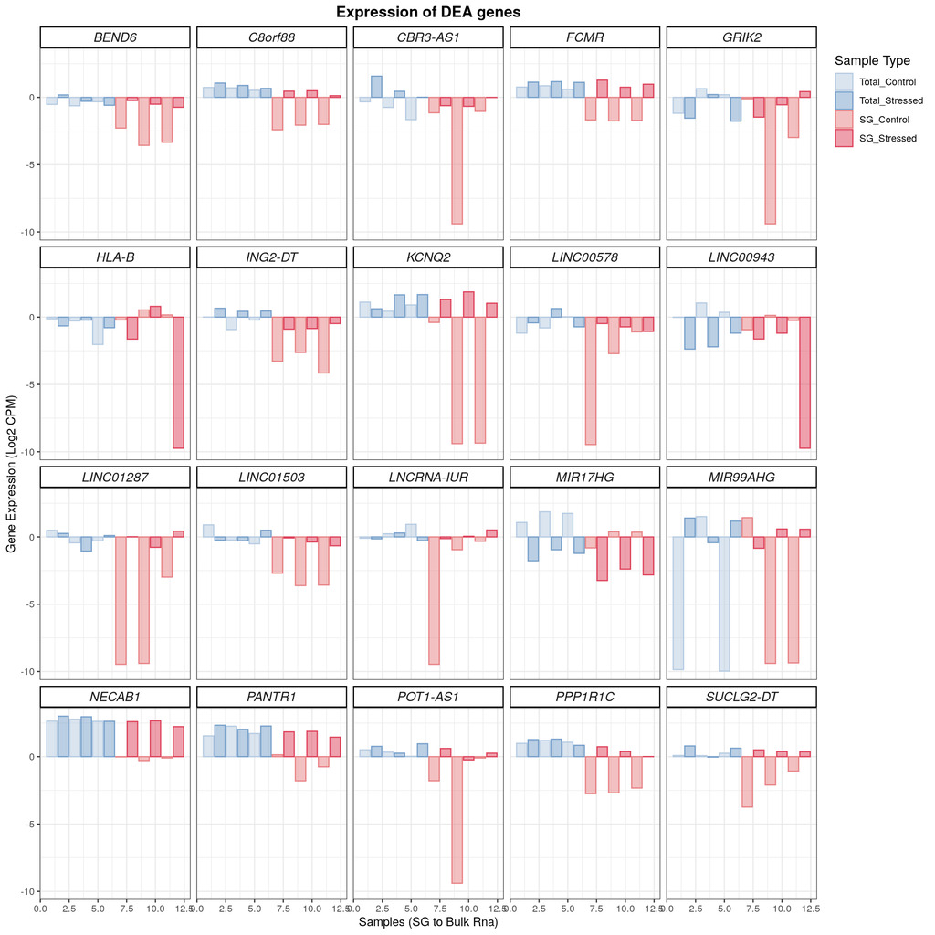

```r
finagenes <- rbind(upmarkers, downmarkers)

dfforexpression <- dfforpca
samplecodes <- data.frame(samples=row.names(dfforexpression), purity=c(1:12))
sampletype <- data.frame(samples=row.names(dfforexpression), sampletype=SampleColouring)
dfforexpression <- t(dfforexpression)
genesforexp <- dfforexpression[row.names(dfforexpression)%in%row.names(finagenes),]
genesforexp <- reshape2::melt(genesforexp)
colnames(genesforexp) <- c("Gene", "samples", "expression")
genesforexp <- merge(genesforexp, samplecodes, by="samples")
genesforexp <- merge(genesforexp, sampletype, by="samples")
genesforexp <- genesforexp[,-1]
genesforexp[,2] <- as.numeric(genesforexp[,2])
genesforexp[,1] <- as.character(genesforexp[,1])
genesforexp <- genesforexp[order(genesforexp$Gene),]


winnyplot <- ggplot(genesforexp, aes(x=purity, y=expression, fill=sampletype, colour=sampletype)) + geom_bar(position="dodge", stat="identity", alpha=0.5) + facet_wrap(.~ Gene, ncol=5)
winnyplot <- winnyplot + scale_fill_manual(name = "Sample Type", values = custom_palette, breaks = unique(SampleColouring)) + scale_colour_manual(name = "Sample Type", values = custom_palette, breaks = unique(SampleColouring))
winnyplot <- winnyplot + theme_bw() + xlab("Samples (SG to Bulk Rna)") + ylab("Gene Expression (Log2 CPM)") + theme(
      strip.text.x = element_text(
        size = 12, face="italic"
        )) +
 theme(
   strip.background = element_rect(
     color="black", fill="#FFFFFF", size=1, linetype="solid"
     )
   ) + theme(
    #legend.position = c(.95, .40),
    legend.justification = c("right", "top"),
    legend.box.just = "right",
    ) + theme(legend.title = element_text(size = 12)) + ggtitle("Expression of DEA genes") + theme(plot.title = element_text(hjust = 0.5, size=14, face="bold"))
winnyplot
```

## GSEA Enrichment

Now that we have our genes of interest, it would also be interesting to see what are the **altered gene sets** between upregulated and downregulated transcripts from the above comparison. Therefore, lets perform a *Gene Set Enrichment Analysis*

```r
#for all genes
DEGenes_SGS.vs.SGT <- DEGenes_SGS.vs.SGT[order(DEGenes_SGS.vs.SGT[,4]),]
gseatool <- DEGenes_SGS.vs.SGT[,4]
gseatool <- as.data.frame(gseatool)
colnames(gseatool)[1] <- "t"
gseatool[,2] <- DEGenes_SGS.vs.SGT$Gene
colnames(gseatool)[2] <- "Symbol"
gseatool <- gseatool[,c(2,1)]

vectorranks <- gseatool$t
names(vectorranks) <- gseatool$Symbol


#to load our pathways
hallmarks.gs <- msigdbr(species = "Homo sapiens", collection =  "H")

hallmarks.gsets <- hallmarks.gs %>% split(x = .$gene_symbol, f = .$gs_name)

for (set in names(hallmarks.gsets)){
  hallmarks.gsets[[set]] <- toupper(hallmarks.gsets[[set]])
}

hallmarks.res <- fgsea(pathways = hallmarks.gsets,
                       stats = vectorranks)
```

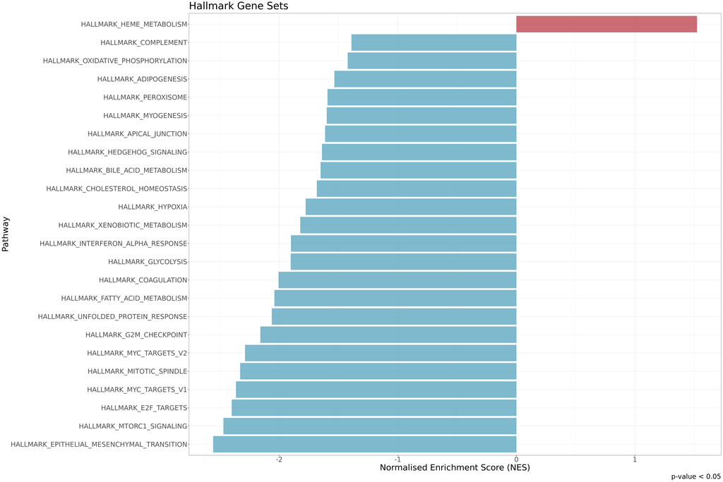

```r
hallmarks.res.tidy <- hallmarks.res %>%
  as_tibble() %>%
  arrange(desc(NES))

hallmarks.res.tidy %>%
  dplyr::select(-leadingEdge, -ES) %>%
  arrange(padj)

hallmark.sg.t <- hallmarks.res.tidy[,c(1,3,6)]
hallmark.sg.t <- as.data.frame(hallmark.sg.t)

#this small part is generic
thresh <- 0.05

#this one is no longer generic
data_to_plot <- hallmarks.res.tidy %>% filter(padj < thresh)

statvec <- c()
for (i in 1:nrow(data_to_plot)){
  if (data_to_plot[i,6] > 0){
    status <- "Upregulated"
  }
 else {
   status <- "Downregulated"
 }
statvec <- c(statvec, status)
}

data_to_plot$Status <- statvec

##-----HALMARK-----
gsea_plot_hall <- ggplot(data_to_plot, aes(reorder(pathway, NES), NES)) +
  geom_col(aes(fill= Status), alpha=0.75) + scale_fill_manual(values = c("#53A2BE","#BA3B46"), name = "Regulation Status", labels = c("Downregulated", "Upregulated"), breaks = c("Downregulated", "Upregulated")) +
  coord_flip() +
  labs(x="Pathway", y="Normalised Enrichment Score (NES)",
       title= "Hallmark Gene Sets",
       caption = paste0("p-value < ", thresh)) + theme(plot.title = element_text(hjust = 1)) +
  theme_bw() + theme(text=element_text(family = "Quicksand")) + theme(legend.position = "none")


gsea_plot_hall+
  theme(text=element_text(size=25,  family="Arial MS"))
```

## GSEA Length

```r
#for all genes
DEGenes_SGS.vs.SGT <- DEGenes_SGS.vs.SGT[order(DEGenes_SGS.vs.SGT[,8]),]
gseatool <- DEGenes_SGS.vs.SGT[,8]
gseatool <- as.data.frame(gseatool)
colnames(gseatool)[1] <- "t"
gseatool[,2] <- DEGenes_SGS.vs.SGT$Gene
colnames(gseatool)[2] <- "Symbol"
gseatool <- gseatool[,c(2,1)]

#for only the genes without the contamination


vectorranks <- log10(gseatool$t)
vectorranks <- scale(vectorranks)
names(vectorranks) <- gseatool$Symbol


#to load our pathways

##-----HALLMARK-----
hallmarks.gs <- msigdbr(species = "Homo sapiens", collection = "H")

hallmarks.gsets <- hallmarks.gs %>% split(x = .$gene_symbol, f = .$gs_name)

for (set in names(hallmarks.gsets)){
  hallmarks.gsets[[set]] <- toupper(hallmarks.gsets[[set]])
}

hallmarks.res <- fgsea(pathways = hallmarks.gsets,
                       stats = vectorranks)
```

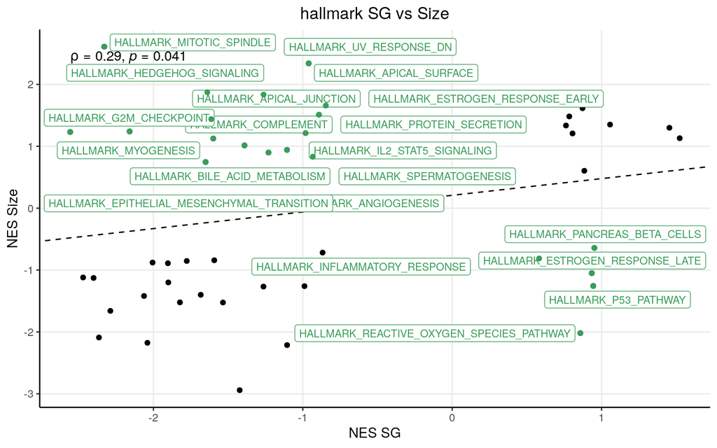

```r
hallmarks.res.tidy <- hallmarks.res %>%
  as_tibble() %>%
  arrange(desc(NES))

hallmarks.res.tidy %>%
  dplyr::select(-leadingEdge, -ES) %>%
  arrange(padj)

hallmark.size.t <- hallmarks.res.tidy[,c(1,3,6)]
hallmark.size.t <- as.data.frame(hallmark.size.t)

#HALLMARK
hallmark.scatter_ak <- merge(hallmark.sg.t, hallmark.size.t, by="pathway")
colnames(hallmark.scatter_ak) <- c("pathway", "sg_pval", "sg", "size_pval", "size")
hallmark.scatter_ak <- na.omit(hallmark.scatter_ak)
res_hallmark <- lm(size ~ sg, hallmark.scatter_ak)

vip.pathways_ak <- as.data.frame(hallmark.scatter_ak[(hallmark.scatter_ak$sg/hallmark.scatter_ak$size)<0,] )



ggplot(hallmark.scatter_ak, aes(x=sg, y=size)) + geom_point(color="black", alpha=01) +   theme_bw()+
 xlab("NES SG") + ylab("NES Size") +
  theme(axis.line = element_line(colour = "black"),
        panel.grid.minor = element_blank(),
        panel.border = element_blank(),
        panel.background = element_blank()) + ggtitle("hallmark SG vs Size")+
  theme(plot.title = element_text(hjust = 0.5)) +
  geom_abline(slope=res_hallmark$coefficients[2], intercept = res_hallmark$coefficients[1], linetype = "dashed") +
  geom_label_repel(vip.pathways_ak[1:ndegs,] , mapping=aes(label=vip.pathways_ak$pathway[1:ndegs]),size=3,point.padding=-0.5, color="#399e5a",max.overlaps = 200)+
  geom_point(data=vip.pathways_ak, aes(x=sg, y= size), color="#399e5a") + stat_cor(method = "spearman", cor.coef.name = "rho")
```

# Comparisons

Is the SpinSim pipeline, which only takes centrifugation into account, a good recapitulation of DC’s SG enrichment? Here, I directly check this.

```r
cor_sim_df <- merge(stress_t, control_t, by="Gene")
cor_sim_df <- merge(cor_sim_df, genelength, by="Gene")


smooth.SG <- lm(stress_t ~ control_t, cor_sim_df)
liner.SG <- rstandard(smooth.SG)
cor_sim_df <-cbind(cor_sim_df, liner.SG)
colnames(cor_sim_df)[5] <- "Residuals"
row.names(cor_sim_df) <- cor_sim_df$Gene
linemarkers <- as.data.frame(cor_sim_df[abs(cor_sim_df$Residuals)>4,])

cor.test(cor_sim_df$stress_t, cor_sim_df$control_t, method="spearman")
```

```
##
##  Spearman's rank correlation rho
##
## data:  cor_sim_df$stress_t and cor_sim_df$control_t
## S = 2.49e+11, p-value < 2.2e-16
## alternative hypothesis: true rho is not equal to 0
## sample estimates:
##      rho
## 0.203375
```

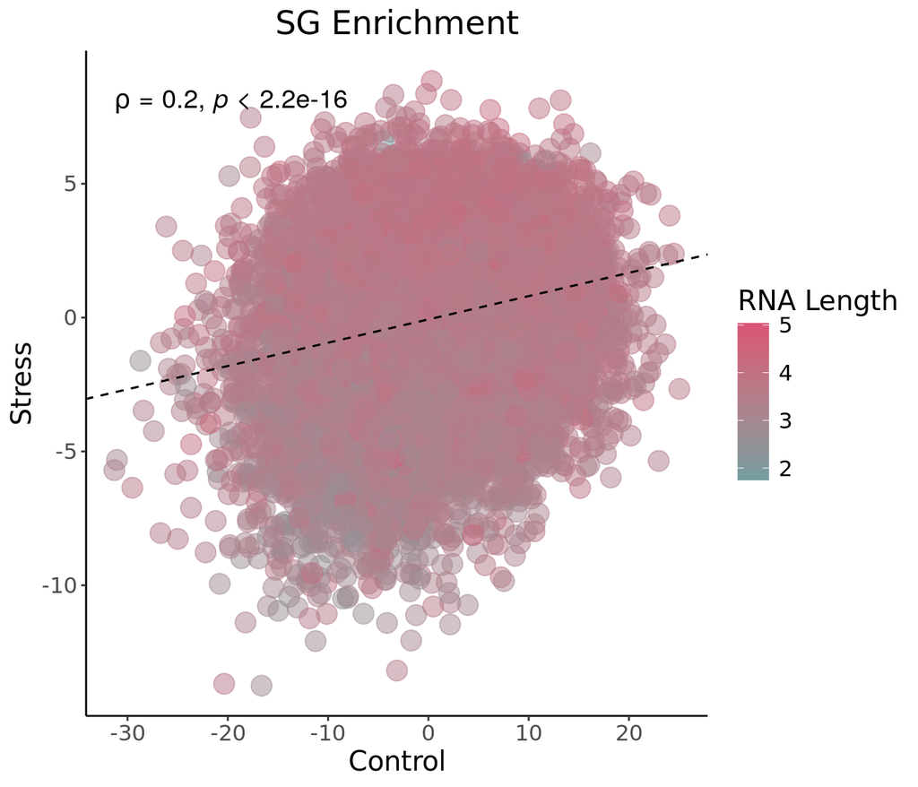

```r
ggplot(cor_sim_df, aes(x=control_t, y=stress_t)) + geom_point(aes(colour=log10(Length)),alpha=0.5, size=5) +   theme_bw()+
 xlab("Control") + ylab("Stress") +
  theme(axis.line = element_line(colour = "black"),
        panel.grid.minor = element_blank(),
        panel.border = element_blank(),
        panel.background = element_blank()) + ggtitle("SG Enrichment")+
  theme(plot.title = element_text(hjust = 0.5))  +
  geom_abline(slope=smooth.SG$coefficients[2], intercept = smooth.SG$coefficients[1], linetype = "dashed")+
  theme(text=element_text(size=15,  family="Arial MS")) + stat_cor(method = "spearman", cor.coef.name = "rho", size=5) +
  theme(plot.title = element_text(hjust = 0.5)) +
  geom_abline(slope = smooth.SG$coefficients[2],
              intercept = smooth.SG$coefficients[1],
              linetype = "dashed") + theme(panel.grid.major = element_blank(), panel.grid.minor = element_blank())+
  scale_colour_gradient(low="#729EA1", high = "#DB5375")+
  labs(colour = "RNA Length")
```

# Complex Linear Models

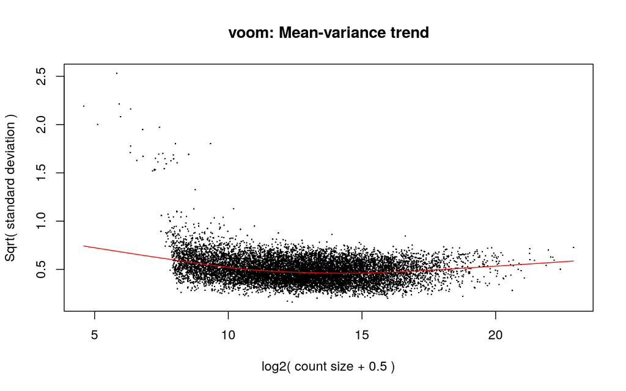

```r
mm <- model.matrix(~0+Sample+ Stress)

D0 <- DGEList(finaltable)

#Then we calculate the normalization factors for these new generated data frames
#Bear in mind this step calculates the normalization factors, but does not normalize itself.
D0 <- calcNormFactors(D0)

y <- voom(D0, mm, plot = T)
```

```r
fitted <- lmFit(y, mm)

head(coef(fitted))
```

```
##           SampleSG SampleTotal StressStressed
## A1BG     1.1545066    2.274756      0.8673295
## A1BG-AS1 1.4763610    1.390700     -0.3234465
## A2M      3.0842713    2.420254     -0.4386039
## A4GALT   0.1913914    0.503780     -0.1445159
## AAAS     8.3577255    7.929344     -0.3938759
## AACS     5.9642082    5.300258     -0.3373860
```

```r
SG.vs.WC <- makeContrasts(SampleSG    - SampleTotal   , levels = colnames(coef(fitted)))


tmp_SG.vs.WC <- contrasts.fit(fitted, SG.vs.WC)


tmp_SG.vs.WC <- eBayes(tmp_SG.vs.WC)


top_SG.vs.WC<- topTable(tmp_SG.vs.WC, sort.by = "logFC", n=Inf)


DEGenes_SG.vs.WC<- top_SG.vs.WC


ndegs=20
```

# SG vs WC

## Volcano Plot

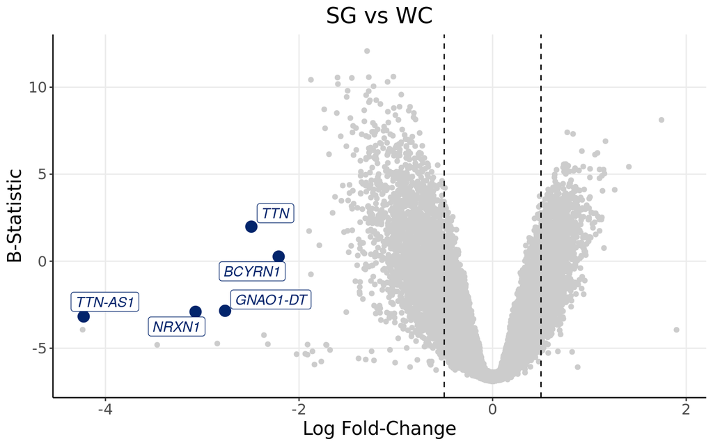

```r
upmarkers <- as.data.frame(DEGenes_SG.vs.WC[DEGenes_SG.vs.WC$logFC>2 & DEGenes_SG.vs.WC$adj.P.Val<0.05,] )
downmarkers <- as.data.frame(DEGenes_SG.vs.WC[DEGenes_SG.vs.WC$logFC< -2 & DEGenes_SG.vs.WC$adj.P.Val<0.05,] )

ggplot(data=DEGenes_SG.vs.WC,
                 aes(x=logFC,
                     y=  B)) +
  geom_point(color="#CCCCCC")+ geom_vline(xintercept = -0.5, linetype="dashed")+geom_vline(xintercept = 0.5, linetype="dashed")+
  theme_bw() + ylab("B-Statistic")+xlab("Log Fold-Change")+
  theme(axis.line = element_line(colour = "black"),
        panel.grid.minor = element_blank(),
        panel.border = element_blank(),
        panel.background = element_blank()) +
  ggtitle("SG vs WC")+
  theme(plot.title = element_text(hjust = 0.5), plot.subtitle = element_text(hjust = 0.5)) +
  geom_point(data=upmarkers, aes(x=logFC, y=  B), color="#A10702",size=4)+
  geom_point(data=downmarkers, aes(x=logFC, y=  B), color="#03256C",size=4)+
  geom_label_repel(upmarkers[1:ndegs,] , mapping=aes(label=row.names(upmarkers)[1:ndegs]),size=4,point.padding=-0.5, color="#A10702",max.overlaps = 20, fontface="italic")+
  geom_label_repel(downmarkers[1:ndegs,] , mapping=aes(label=row.names(downmarkers)[1:ndegs]),size=4,point.padding=-0.5, color="#03256C",max.overlaps = 20, fontface="italic")+
  theme(text=element_text(size=15,  family="Arial MS"))
```

## Volcano Plot with Gene Length

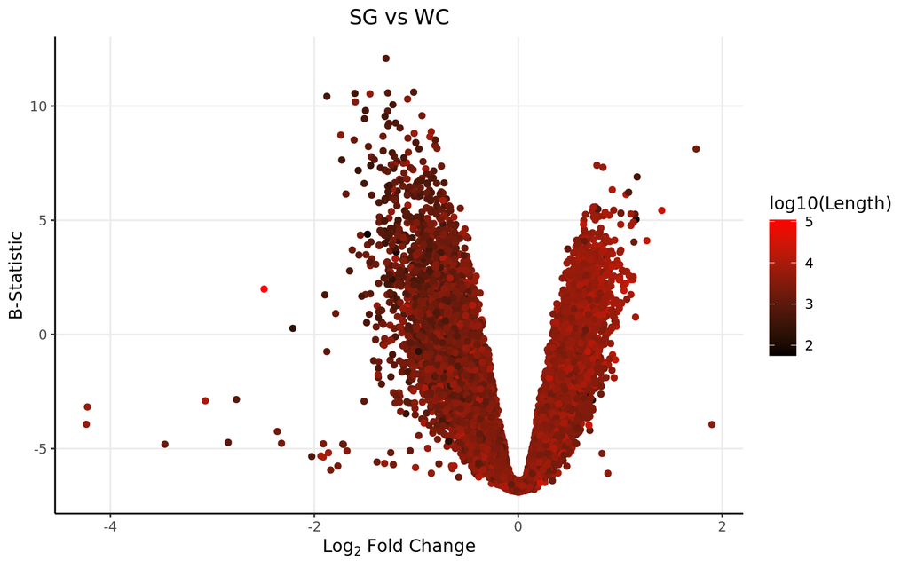

```r
DEGenes_SG.vs.WC$Gene <- row.names(DEGenes_SG.vs.WC)
colnames(genelength) <- c("Length","Gene")
DEGenes_SG.vs.WC <- merge(DEGenes_SG.vs.WC, genelength, by="Gene")

ggplot(data=DEGenes_SG.vs.WC,
                 aes(x=logFC,
                     y=  B)) +
  geom_point(aes(color=log10(Length)))+
  theme_bw() +
  theme(axis.line = element_line(colour = "black"),
        panel.grid.minor = element_blank(),
        panel.border = element_blank(),
        panel.background = element_blank()) +
  ggtitle("SG vs WC")+ xlab(expression(Log[2] ~ Fold ~ Change)) + ylab("B-Statistic") +
  theme(plot.title = element_text(hjust = 0.5))  +
  scale_colour_gradient(low = "black", high = "red")+ theme(text=element_text(family = "Quicksand"))
```

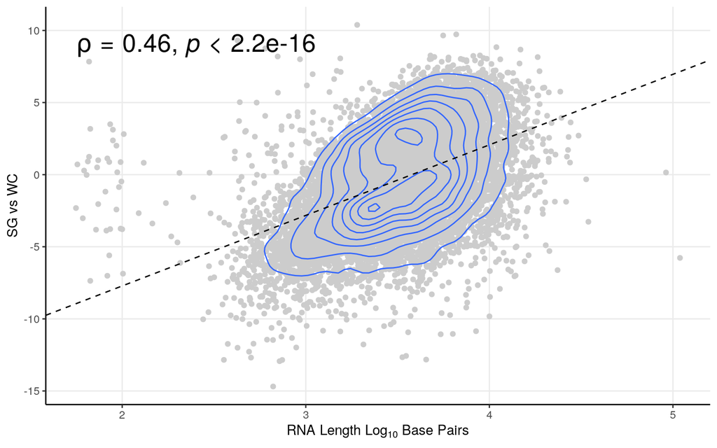

```r
smooth.SG <- lm(t~log10(Length), DEGenes_SG.vs.WC)
liner.SG <- rstandard(smooth.SG)
DEGenes_SG.vs.WC <-cbind(DEGenes_SG.vs.WC, liner.SG)
colnames(DEGenes_SG.vs.WC)[9] <- "Residuals"
row.names(DEGenes_SG.vs.WC) <- DEGenes_SG.vs.WC$Gene
linemarkers <- as.data.frame(DEGenes_SG.vs.WC[abs(DEGenes_SG.vs.WC$Residuals)>4,])

# Calculate the Spearman correlation coefficient
spearman_corr <- cor(DEGenes_SG.vs.WC$t, log10(DEGenes_SG.vs.WC$Length), method = "spearman")



ggplot(DEGenes_SG.vs.WC, aes(y=t, x=log10(Length))) + geom_point(color="#CCCCCC", alpha=1) +   theme_bw()+ geom_density_2d()+
 ylab("SG vs WC") + xlab(expression(RNA ~ Length ~ Log[10] ~ Base ~ Pairs)) +
  theme(axis.line = element_line(colour = "black"),
        panel.grid.minor = element_blank(),
        panel.border = element_blank(),
        panel.background = element_blank()) +
  theme(plot.title = element_text(hjust = 0.5))  +
  geom_abline(slope=smooth.SG$coefficients[2], intercept = smooth.SG$coefficients[1], linetype = "dashed")+ stat_cor(method = "spearman", cor.coef.name = "rho",size=7)
```

A lenght bias is seen.

## GSEA Enrichment

Now that we have our genes of interest, it would also be interesting to see what are the **altered gene sets** between upregulated and downregulated transcripts from the above comparison. Therefore, lets perform a *Gene Set Enrichment Analysis*

```r
#for all genes
DEGenes_SG.vs.WC <- DEGenes_SG.vs.WC[order(DEGenes_SG.vs.WC[,4]),]
gseatool <- DEGenes_SG.vs.WC[,4]
gseatool <- as.data.frame(gseatool)
colnames(gseatool)[1] <- "t"
gseatool[,2] <- DEGenes_SG.vs.WC$Gene
colnames(gseatool)[2] <- "Symbol"
gseatool <- gseatool[,c(2,1)]

vectorranks <- gseatool$t
names(vectorranks) <- gseatool$Symbol


#to load our pathways
hallmarks.gs <- msigdbr(species = "Homo sapiens", collection =  "H")

hallmarks.gsets <- hallmarks.gs %>% split(x = .$gene_symbol, f = .$gs_name)

for (set in names(hallmarks.gsets)){
  hallmarks.gsets[[set]] <- toupper(hallmarks.gsets[[set]])
}

hallmarks.res <- fgsea(pathways = hallmarks.gsets,
                       stats = vectorranks)
```

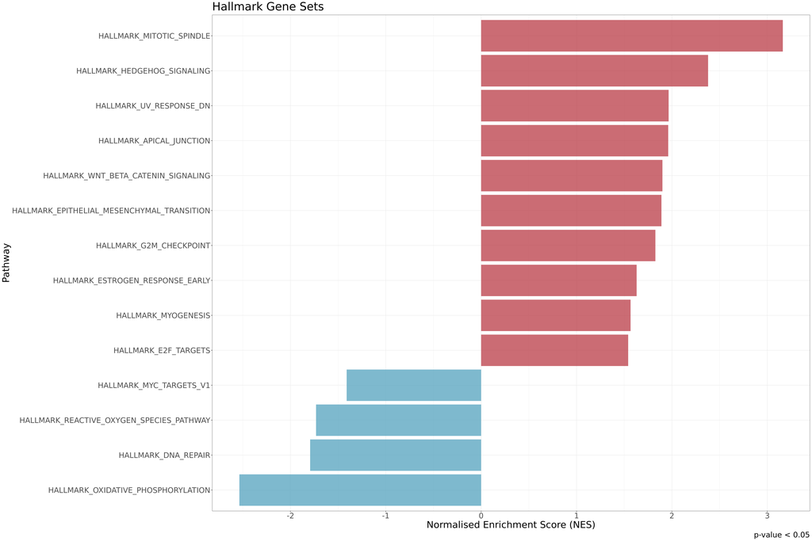

```r
hallmarks.res.tidy <- hallmarks.res %>%
  as_tibble() %>%
  arrange(desc(NES))

hallmarks.res.tidy %>%
  dplyr::select(-leadingEdge, -ES) %>%
  arrange(padj)

hallmark.sg.t <- hallmarks.res.tidy[,c(1,3,6)]
hallmark.sg.t <- as.data.frame(hallmark.sg.t)

#this small part is generic
thresh <- 0.05

#this one is no longer generic
data_to_plot <- hallmarks.res.tidy %>% filter(padj < thresh)

statvec <- c()
for (i in 1:nrow(data_to_plot)){
  if (data_to_plot[i,6] > 0){
    status <- "Upregulated"
  }
 else {
   status <- "Downregulated"
 }
statvec <- c(statvec, status)
}

data_to_plot$Status <- statvec

##-----HALMARK-----
gsea_plot_hall <- ggplot(data_to_plot, aes(reorder(pathway, NES), NES)) +
  geom_col(aes(fill= Status), alpha=0.75) + scale_fill_manual(values = c("#53A2BE","#BA3B46"), name = "Regulation Status", labels = c("Downregulated", "Upregulated"), breaks = c("Downregulated", "Upregulated")) +
  coord_flip() +
  labs(x="Pathway", y="Normalised Enrichment Score (NES)",
       title= "Hallmark Gene Sets",
       caption = paste0("p-value < ", thresh)) + theme(plot.title = element_text(hjust = 1)) +
  theme_bw() + theme(text=element_text(family = "Quicksand")) + theme(legend.position = "none")


gsea_plot_hall+
  theme(text=element_text(size=25,  family="Arial MS"))
```

## GSEA Length

Now, since SGs are enriched for longer transcripts, these pathways may simply be the ones which are tipically enriched in longer transcripts. Therefore, I will repeat the analysis, but using transcript lenght instead of t-statistic.

```r
#for all genes
DEGenes_SG.vs.WC <- DEGenes_SG.vs.WC[order(DEGenes_SG.vs.WC[,8]),]
gseatool <- DEGenes_SG.vs.WC[,8]
gseatool <- as.data.frame(gseatool)
colnames(gseatool)[1] <- "t"
gseatool[,2] <- DEGenes_SG.vs.WC$Gene
colnames(gseatool)[2] <- "Symbol"
gseatool <- gseatool[,c(2,1)]

#for only the genes without the contamination


vectorranks <- log10(gseatool$t)
vectorranks <- scale(vectorranks)
names(vectorranks) <- gseatool$Symbol


#to load our pathways

##-----HALLMARK-----
hallmarks.gs <- msigdbr(species = "Homo sapiens", collection = "H")

hallmarks.gsets <- hallmarks.gs %>% split(x = .$gene_symbol, f = .$gs_name)

for (set in names(hallmarks.gsets)){
  hallmarks.gsets[[set]] <- toupper(hallmarks.gsets[[set]])
}

hallmarks.res <- fgsea(pathways = hallmarks.gsets,
                       stats = vectorranks)
```

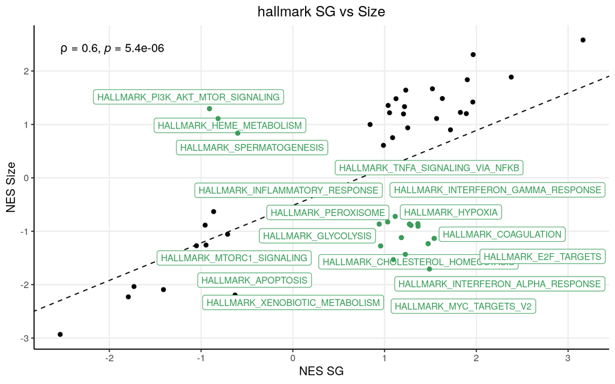

```r
hallmarks.res.tidy <- hallmarks.res %>%
  as_tibble() %>%
  arrange(desc(NES))

hallmarks.res.tidy %>%
  dplyr::select(-leadingEdge, -ES) %>%
  arrange(padj)

hallmark.size.t <- hallmarks.res.tidy[,c(1,3,6)]
hallmark.size.t <- as.data.frame(hallmark.size.t)

#HALLMARK
hallmark.scatter_ak <- merge(hallmark.sg.t, hallmark.size.t, by="pathway")
colnames(hallmark.scatter_ak) <- c("pathway", "sg_pval", "sg", "size_pval", "size")
hallmark.scatter_ak <- na.omit(hallmark.scatter_ak)
res_hallmark <- lm(size ~ sg, hallmark.scatter_ak)

vip.pathways_ak <- as.data.frame(hallmark.scatter_ak[(hallmark.scatter_ak$sg/hallmark.scatter_ak$size)<0,] )



ggplot(hallmark.scatter_ak, aes(x=sg, y=size)) + geom_point(color="black", alpha=01) +   theme_bw()+
 xlab("NES SG") + ylab("NES Size") +
  theme(axis.line = element_line(colour = "black"),
        panel.grid.minor = element_blank(),
        panel.border = element_blank(),
        panel.background = element_blank()) + ggtitle("hallmark SG vs Size")+
  theme(plot.title = element_text(hjust = 0.5)) +
  geom_abline(slope=res_hallmark$coefficients[2], intercept = res_hallmark$coefficients[1], linetype = "dashed") +
  geom_label_repel(vip.pathways_ak[1:ndegs,] , mapping=aes(label=vip.pathways_ak$pathway[1:ndegs]),size=3,point.padding=-0.5, color="#399e5a",max.overlaps = 200)+
  geom_point(data=vip.pathways_ak, aes(x=sg, y= size), color="#399e5a") + stat_cor(method = "spearman", cor.coef.name = "rho")
```

# Controlled SG Signal

```r
Sample <- factor(Sample, levels = c("Total", "SG"))
mm <- model.matrix(~1+Sample*Stress)

# Here, I center my model matrix
mm[,2] <- mm[,2] - mean(mm[,2])
mm[,3] <- mm[,3] - mean(mm[,3])
mm[,4] <- mm[,2]*mm[,3]

D0 <- DGEList(finaltable)

#Then we calculate the normalization factors for these new generated data frames
#Bear in mind this step calculates the normalization factors, but does not normalize itself.
D0 <- calcNormFactors(D0)

y <- voom(D0, mm, plot = T)
```

```r
fitted <- lmFit(y, mm)

head(coef(fitted))
```

```
##          (Intercept)    SampleSG StressStressed SampleSG:StressStressed
## A1BG       2.1368346 -1.16074158      0.9144834               0.6492803
## A1BG-AS1   1.2680269  0.08728711     -0.3227170               0.3044127
## A2M        2.5396346  0.65386038     -0.4205407              -1.0012289
## A4GALT     0.2652325 -0.31925292     -0.1088786               1.0269942
## AAAS       7.9423110  0.43517216     -0.4013082              -1.1353895
## AACS       5.4638922  0.66292069     -0.3362768              -0.8984178
```

```r
tmp_SG <- eBayes(fitted)

top_SG <- topTable(tmp_SG, 4, sort.by = "logFC", n=Inf)

DEGenes_SG <- top_SG

ndegs=20
```

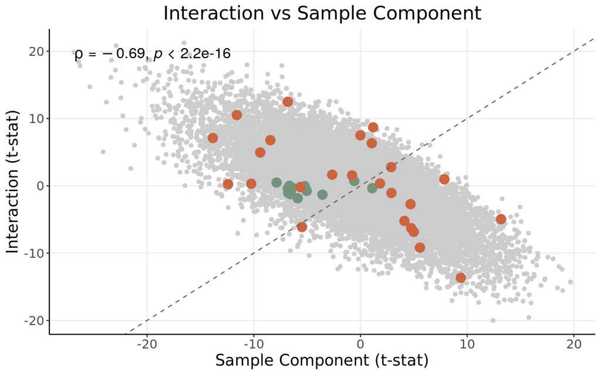

```r
top_interact <- topTable(tmp_SG, coef="SampleSG:StressStressed", sort.by="logFC", n=Inf)
top_sample   <- topTable(tmp_SG, coef="SampleSG", sort.by="logFC", n=Inf)
top_stress   <- topTable(tmp_SG, coef="StressStressed", sort.by="logFC", n=Inf)

interact_t <- data.frame(Gene=row.names(top_interact), interact_t=top_interact$t)
sample_t   <- data.frame(Gene=row.names(top_sample), sample_t=top_sample$t)
stress_t   <- data.frame(Gene=row.names(top_stress), stress_t=top_stress$t)

MitoGenes <- fread("~/MitoGenes.txt")[[1]]
NucGenes <- fread("~/rnalocate_mito_filt.csv")[[1]]

## ---- Interaction vs Sample component ----

comp1_df <- merge(interact_t, sample_t, by="Gene")
row.names(comp1_df) <- comp1_df$Gene
MitoData_c1 <- comp1_df[comp1_df$Gene %in% MitoGenes, ]
NucData_c1  <- comp1_df[comp1_df$Gene %in% NucGenes, ]

spearman_c1 <- cor(comp1_df$interact_t, comp1_df$sample_t, method = "spearman")

(p_c1 <- ggplot(comp1_df, aes(x=sample_t, y=interact_t)) +
  geom_point(color="#CCCCCC") +
  geom_point(data=MitoData_c1, aes(x=sample_t, y=interact_t), color="#73937E", size=4) +
  geom_point(data=NucData_c1, aes(x=sample_t, y=interact_t), color="#CB643F", size=4) +
  geom_abline(slope=1, intercept=0, linetype="dashed", color="grey40") +
  theme_bw() + ylab("Interaction (t-stat)") + xlab("Sample Component (t-stat)") +
  theme(axis.line = element_line(colour = "black"),
        panel.grid.minor = element_blank(),
        panel.border = element_blank(),
        panel.background = element_blank()) +
  ggtitle("Interaction vs Sample Component") +
  theme(plot.title = element_text(hjust = 0.5)) +
  theme(text=element_text(size=15, family="Arial MS")) +
  stat_cor(method = "spearman", cor.coef.name = "rho", size=5))
```

```r
png("~/Projects/StressGranules/SGPAPER/Images/PNG/Iade_InteractionVsSample.png", width = 7, height=6, units = "in", res=300)
p_c1
dev.off()
```

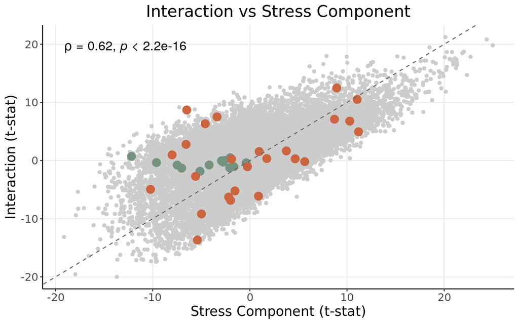

```r
## ---- Interaction vs Stress component ----

comp2_df <- merge(interact_t, stress_t, by="Gene")
row.names(comp2_df) <- comp2_df$Gene
MitoData_c2 <- comp2_df[comp2_df$Gene %in% MitoGenes, ]
NucData_c2  <- comp2_df[comp2_df$Gene %in% NucGenes, ]

spearman_c2 <- cor(comp2_df$interact_t, comp2_df$stress_t, method = "spearman")

(p_c2 <- ggplot(comp2_df, aes(x=stress_t, y=interact_t)) +
  geom_point(color="#CCCCCC") +
  geom_point(data=MitoData_c2, aes(x=stress_t, y=interact_t), color="#73937E", size=4) +
  geom_point(data=NucData_c2, aes(x=stress_t, y=interact_t), color="#CB643F", size=4) +
  geom_abline(slope=1, intercept=0, linetype="dashed", color="grey40") +
  theme_bw() + ylab("Interaction (t-stat)") + xlab("Stress Component (t-stat)") +
  theme(axis.line = element_line(colour = "black"),
        panel.grid.minor = element_blank(),
        panel.border = element_blank(),
        panel.background = element_blank()) +
  ggtitle("Interaction vs Stress Component") +
  theme(plot.title = element_text(hjust = 0.5)) +
  theme(text=element_text(size=15, family="Arial MS")) +
  stat_cor(method = "spearman", cor.coef.name = "rho", size=5))
```

```r
png("~/Projects/StressGranules/SGPAPER/Images/PNG/Iade_InteractionVsStress.png", width = 7, height=6, units = "in", res=300)
p_c2
dev.off()
```

## Volcano Plot

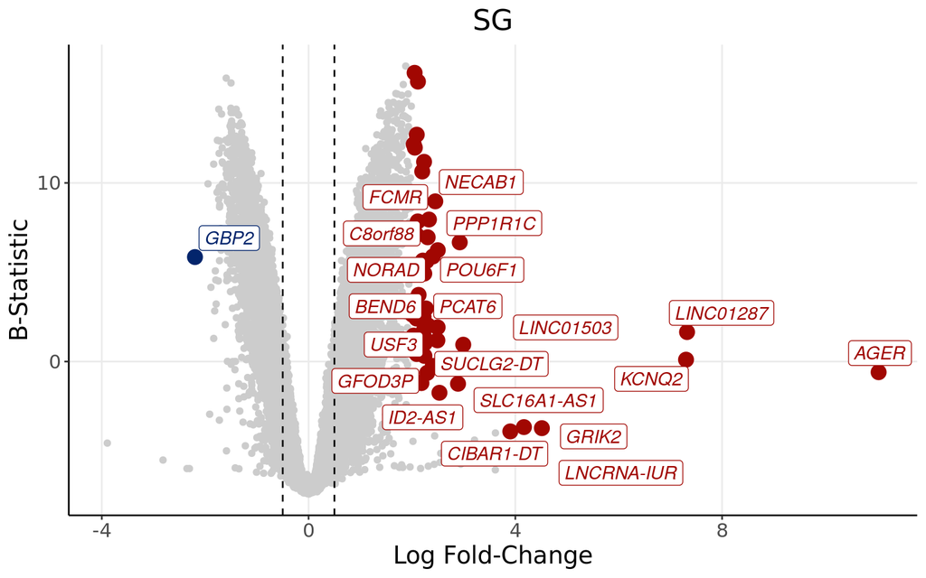

```r
write.table(x = DEGenes_SG,
            file = "~/Projects/StressGranules/SGPAPER/RealSGs/RealvIadevaia.txt", sep="\t", col.names = TRUE, row.names = TRUE, quote=FALSE)

upmarkers <- as.data.frame(DEGenes_SG[DEGenes_SG$logFC>2 & DEGenes_SG$adj.P.Val<0.05,] )
downmarkers <- as.data.frame(DEGenes_SG[DEGenes_SG$logFC< -2 & DEGenes_SG$adj.P.Val<0.05,] )

ggplot(data=DEGenes_SG,
                 aes(x=logFC,
                     y=  B)) +
  geom_point(color="#CCCCCC")+ geom_vline(xintercept = -0.5, linetype="dashed")+geom_vline(xintercept = 0.5, linetype="dashed")+
  theme_bw() + ylab("B-Statistic")+xlab("Log Fold-Change")+
  theme(axis.line = element_line(colour = "black"),
        panel.grid.minor = element_blank(),
        panel.border = element_blank(),
        panel.background = element_blank()) +
  ggtitle("SG")+
  theme(plot.title = element_text(hjust = 0.5), plot.subtitle = element_text(hjust = 0.5)) +
  geom_point(data=upmarkers, aes(x=logFC, y=  B), color="#A10702",size=4)+
  geom_point(data=downmarkers, aes(x=logFC, y=  B), color="#03256C",size=4)+
  geom_label_repel(upmarkers[1:ndegs,] , mapping=aes(label=row.names(upmarkers)[1:ndegs]),size=4,point.padding=-0.5, color="#A10702",max.overlaps = 20, fontface="italic")+
  geom_label_repel(downmarkers[1:ndegs,] , mapping=aes(label=row.names(downmarkers)[1:ndegs]),size=4,point.padding=-0.5, color="#03256C",max.overlaps = 20, fontface="italic")+
  theme(text=element_text(size=15,  family="Arial MS"))
```

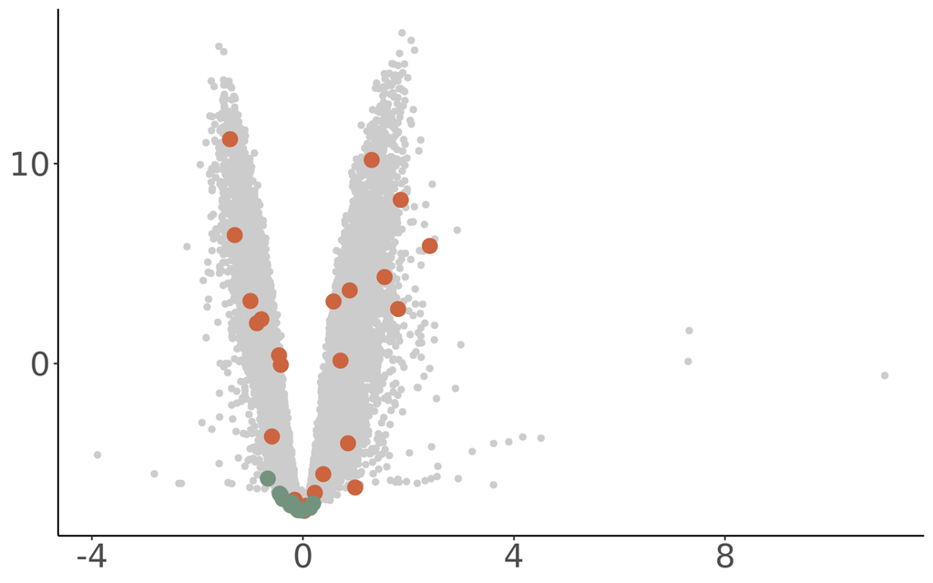

```r
DEGenes<- DEGenes_SG
MitoGenes <- fread("~/MitoGenes.txt")[[1]]
MitoData <- DEGenes[rownames(DEGenes) %in% MitoGenes, ]
NucGenes <- fread("~/rnalocate_mito_filt.csv")[[1]]
NucData <- DEGenes[rownames(DEGenes) %in% NucGenes, ]
(m <- ggplot(data=DEGenes,
                 aes(x=logFC,
                     y=B)) +
  geom_point(color="#CCCCCC") +
  geom_point(data=NucData, aes(x=logFC, y=B), color="#CB643F", size=4) +
  geom_point(data=MitoData, aes(x=logFC, y=B), color="#73937E", size=4) +
  ylab("B-Statistic") +
  xlab(expression(Log[2]~"Fold-Change")) +
  theme(
    axis.line = element_line(colour = "black"),
    panel.grid.major = element_blank(),   # remove major gridlines
    panel.grid.minor = element_blank(),   # remove minor gridlines
    panel.border = element_blank(),
    panel.background = element_blank(),
    axis.title = element_blank()
  ) +
  theme(plot.title = element_text(hjust = 0.5), plot.subtitle = element_text(hjust = 0.5)) +
  theme(text=element_text(size=25, family="Arial MS")))
```

```r
png("~/Projects/StressGranules/SGPAPER/Images/PNG/IadeMito.png", width = 7, height=6, units = "in", res=300)
m
dev.off()
```

# MA Plot

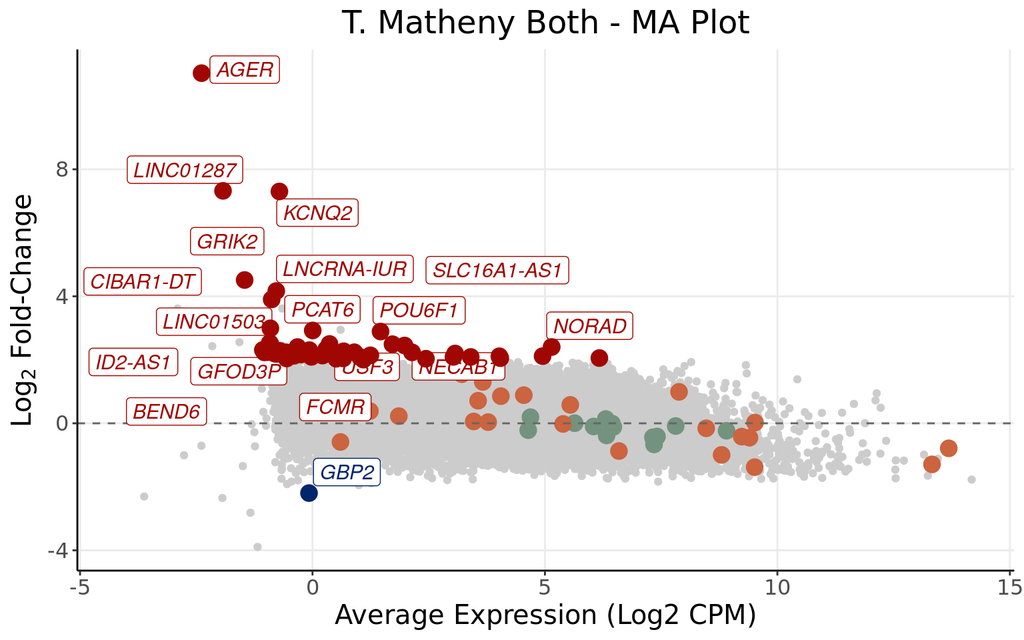

```r
# MA plot: mean expression (x) vs logFC (y), same highlighting scheme as the volcano

ggplot(data=DEGenes,
                 aes(x=AveExpr,
                     y=logFC)) +
  geom_point(color="#CCCCCC") +
  geom_point(data=MitoData, aes(x=AveExpr, y=logFC), color="#73937E", size=4) +
  geom_point(data=NucData, aes(x=AveExpr, y=logFC), color="#CB643F", size=4) +
  geom_hline(yintercept = 0, linetype="dashed", color="grey40") +
  theme_bw() + ylab(expression(Log[2]~"Fold-Change")) + xlab("Average Expression (Log2 CPM)") +
  theme(axis.line = element_line(colour = "black"),
        panel.grid.minor = element_blank(),
        panel.border = element_blank(),
        panel.background = element_blank()) +
  ggtitle("T. Matheny Both - MA Plot") +
  theme(plot.title = element_text(hjust = 0.5), plot.subtitle = element_text(hjust = 0.5)) +
  geom_label_repel(upmarkers[1:ndegs,], mapping=aes(x=AveExpr, y=logFC, label=row.names(upmarkers)[1:ndegs]), size=4, point.padding=-0.5, color="#A10702", max.overlaps=20, fontface="italic") +
  geom_label_repel(downmarkers[1:ndegs,], mapping=aes(x=AveExpr, y=logFC, label=row.names(downmarkers)[1:ndegs]), size=4, point.padding=-0.5, color="#03256C", max.overlaps=20, fontface="italic") +
  geom_point(data=upmarkers, aes(x=AveExpr, y=logFC), color="#A10702", size=4) +
  geom_point(data=downmarkers, aes(x=AveExpr, y=logFC), color="#03256C", size=4) +
  theme(text=element_text(size=15, family="Arial MS"))
```

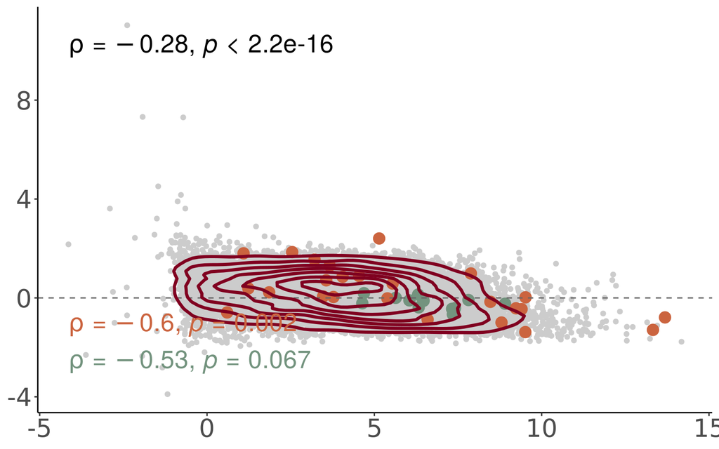

```r
# Publication-style version, stripped of axis titles, matching your "m" plot
(ma <- ggplot(data=DEGenes,
                 aes(x=AveExpr,
                     y=logFC)) +
  geom_point(color="#CCCCCC") +
  geom_point(data=MitoData, aes(x=AveExpr, y=logFC), color="#73937E", size=4) +
  geom_point(data=NucData, aes(x=AveExpr, y=logFC), color="#CB643F", size=4) +
  geom_hline(yintercept = 0, linetype="dashed", color="grey40") +
  ylab(expression(Log[2]~"Fold-Change")) +
  xlab("Average Expression (Log2 CPM)") + geom_density2d(color = "#800020", size = 1.2) + stat_cor(method = "spearman", cor.coef.name = "rho", size=7)+
  stat_cor(data = MitoData, aes(x=AveExpr, y=logFC), method = "spearman",
           cor.coef.name = "rho", size=7, color = "#73937E", label.y.npc = 0.1) +
  stat_cor(data = NucData, aes(x=AveExpr, y=logFC), method = "spearman",
           cor.coef.name = "rho", size=7, color = "#CB643F", label.y.npc = 0.2) +
  theme(
    axis.line = element_line(colour = "black"),
    panel.grid.major = element_blank(),
    panel.grid.minor = element_blank(),
    panel.border = element_blank(),
    panel.background = element_blank(),
    axis.title = element_blank()
  ) +
  theme(plot.title = element_text(hjust = 0.5), plot.subtitle = element_text(hjust = 0.5)) +
  theme(text=element_text(size=25, family="Arial MS")))
```

```r
png("~/Projects/StressGranules/SGPAPER/Images/PNG/IadeMito_MA.png", width = 7, height=6, units = "in", res=300)
ma
dev.off()
```

## MA Plot

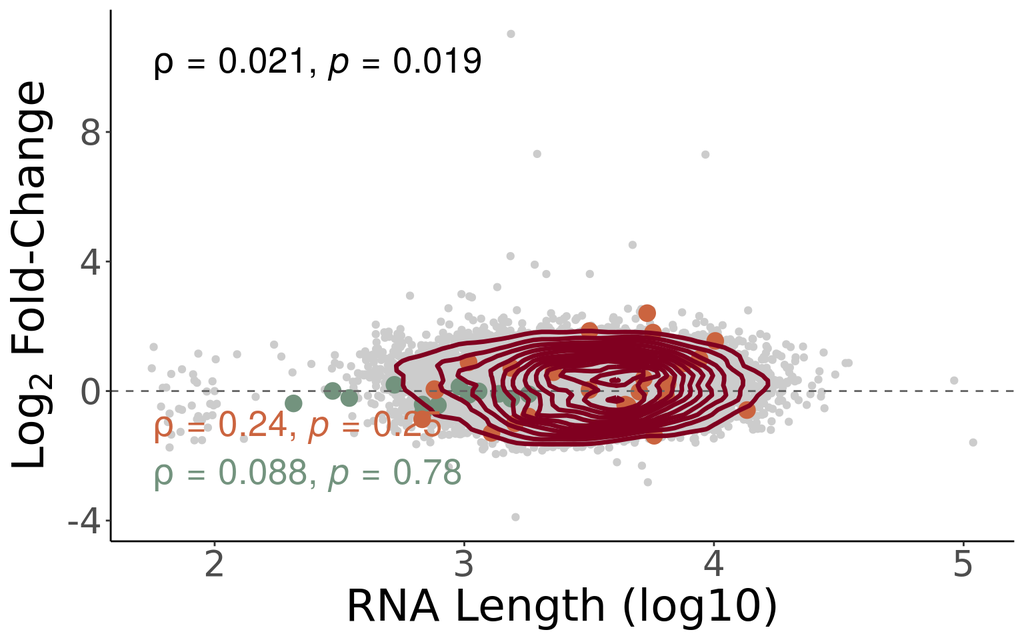

```r
MitoGenes <- fread("~/MitoGenes.txt")[[1]]

genelength <- read.csv("~/Projects/StressGranules/SG_Transcriptome/RP_Data_2021/TrimmedSamples/alignment_STAR/TranscriptLenght.txt", header=T)
genelength <- subset(genelength, Ensembl.Canonical==1)
genelength <- subset(genelength, Gene.name!="")
genelength <- genelength %>%
  group_by(Gene.name) %>%
  slice(which.max(Transcript.length..including.UTRs.and.CDS.)) %>%
  ungroup()
genelength <- genelength[,-c(2,3)]
colnames(genelength) <- c("Length", "Gene")

genelength$Cromo <- ifelse(genelength$Gene %in% MitoGenes, "Mito", "Other")

# Apply the length-based weight formula
genelength$S <- ifelse(
  genelength$Cromo == "Mito",
  (genelength$Length)^(1/3) * 3.23e-11 + 1.17e-9,   # Formula for mitochondrial RNAs
  (genelength$Length)^(1/3) * 6.09e-11 + 3.88e-10    # Formula for other RNAs
)
DEGenes$Gene <- row.names(DEGenes)
DEGenes <- merge(DEGenes, genelength, by="Gene")
MitoGenes <- fread("~/MitoGenes.txt")[[1]]
MitoData <- DEGenes[DEGenes$Gene %in% MitoGenes, ]
NucGenes <- fread("~/rnalocate_mito_filt.csv")[[1]]
NucData <- DEGenes[DEGenes$Gene %in% NucGenes, ]

# Publication-style version, stripped of axis titles, matching your "m" plot
(ma <- ggplot(data=DEGenes,
                 aes(x=log10(Length),
                     y=logFC)) +
  geom_point(color="#CCCCCC") +
  geom_point(data=MitoData, aes(x=log10(Length), y=logFC), color="#73937E", size=4) +
  geom_point(data=NucData, aes(x=log10(Length), y=logFC), color="#CB643F", size=4) +
  geom_hline(yintercept = 0, linetype="dashed", color="grey40") +
  ylab(expression(Log[2]~"Fold-Change")) + geom_density2d(color = "#800020", size = 1.2) + stat_cor(method = "spearman", cor.coef.name = "rho", size=7)+
  stat_cor(data = MitoData, aes(x=log10(Length), y=logFC), method = "spearman",
           cor.coef.name = "rho", size=7, color = "#73937E", label.y.npc = 0.1) +
  stat_cor(data = NucData, aes(x=log10(Length), y=logFC), method = "spearman",
           cor.coef.name = "rho", size=7, color = "#CB643F", label.y.npc = 0.2) +
  xlab("RNA Length (log10)") +
  theme(
    axis.line = element_line(colour = "black"),
    panel.grid.major = element_blank(),
    panel.grid.minor = element_blank(),
    panel.border = element_blank(),
    panel.background = element_blank()
  ) +
  theme(plot.title = element_text(hjust = 0.5), plot.subtitle = element_text(hjust = 0.5)) +
  theme(text=element_text(size=25, family="Arial MS")))
```

```r
png("~/Projects/StressGranules/SGPAPER/Images/PNG/IadeMito_MA_length.png", width = 7, height=6, units = "in", res=300)
ma
dev.off()
```

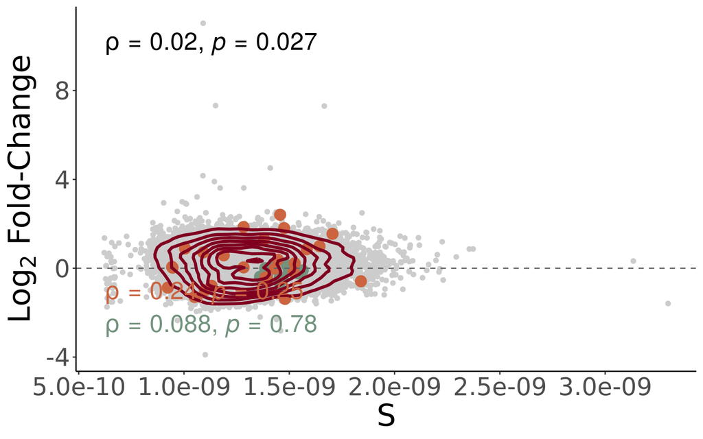

```r
# Publication-style version, stripped of axis titles, matching your "m" plot
(ma <- ggplot(data=DEGenes,
                 aes(x=(S),
                     y=logFC)) +
  geom_point(color="#CCCCCC") +
  geom_point(data=MitoData, aes(x=(S), y=logFC), color="#73937E", size=4) +
  geom_point(data=NucData, aes(x=(S), y=logFC), color="#CB643F", size=4) +
  geom_hline(yintercept = 0, linetype="dashed", color="grey40") +
  ylab(expression(Log[2]~"Fold-Change")) + geom_density2d(color = "#800020", size = 1.2) + stat_cor(method = "spearman", cor.coef.name = "rho", size=7)+
  stat_cor(data = MitoData, aes(x=S, y=logFC), method = "spearman",
           cor.coef.name = "rho", size=7, color = "#73937E", label.y.npc = 0.1) +
  stat_cor(data = NucData, aes(x=S, y=logFC), method = "spearman",
           cor.coef.name = "rho", size=7, color = "#CB643F", label.y.npc = 0.2) +
  xlab("S") +
  theme(
    axis.line = element_line(colour = "black"),
    panel.grid.major = element_blank(),
    panel.grid.minor = element_blank(),
    panel.border = element_blank(),
    panel.background = element_blank()
  ) +
  theme(plot.title = element_text(hjust = 0.5), plot.subtitle = element_text(hjust = 0.5)) +
  theme(text=element_text(size=25, family="Arial MS")))
```

```r
png("~/Projects/StressGranules/SGPAPER/Images/PNG/IadeMito_MA_S.png", width = 7, height=6, units = "in", res=300)
ma
dev.off()
```

## Violins

```r
library(data.table)
library(dplyr)
library(ggplot2)
library(rstatix)
expression.df <- y$E
sample_grp <- Sample
stress_grp <- Stress
Condition  <- interaction(sample_grp, stress_grp, sep=".")

custom_palette <- c(
  "Total.Control"  = "#a2d1e6",
  "Total.Stressed" = "#769fca",
  "SG.Control"     = "#e88184",
  "SG.Stressed"    = "#de425b"
)

# ── 1. Gene sets already loaded earlier in the script (MitoGenes, NucGenes) ──
mito_genes_present <- MitoGenes[MitoGenes %in% rownames(expression.df)]
nuc_genes_present  <- NucGenes[NucGenes %in% rownames(expression.df)]
cat(length(mito_genes_present), "Mito genes found in expression matrix\n")
```

```
## 13 Mito genes found in expression matrix
```

```r
cat(length(nuc_genes_present), "Nuc genes found in expression matrix\n")
```

```
## 25 Nuc genes found in expression matrix
```

```r
# ── 2. Rank all genes per sample (1 = least expressed) ───────────────────────
rank_matrix <- apply(expression.df, 2, function(x) rank(x, ties.method = "average"))
rank_matrix <- as.data.frame(rank_matrix)

# ── 3. Compute a rank-sum score per sample, one gene set at a time ───────────
compute_score <- function(genes, rank_matrix, n_total) {
  colSums(rank_matrix[genes, , drop = FALSE]) / n_total
}

mito_score <- compute_score(mito_genes_present, rank_matrix, nrow(expression.df))
nuc_score  <- compute_score(nuc_genes_present, rank_matrix, nrow(expression.df))

# ── 4. Assemble plot dataframe, long format across both gene sets ────────────
score_df <- rbind(
  data.frame(Sample = colnames(expression.df), Score = as.numeric(mito_score),
             SampleGrp = sample_grp, StressGrp = stress_grp,
             Condition = Condition, GeneSet = "Mito"),
  data.frame(Sample = colnames(expression.df), Score = as.numeric(nuc_score),
             SampleGrp = sample_grp, StressGrp = stress_grp,
             Condition = Condition, GeneSet = "Nuc")
)

# ── 5. Statistics per gene set: two-way ANOVA (Sample*Stress), interaction term ──
stat_labels <- score_df %>%
  group_by(GeneSet) %>%
  group_modify(~{
    aov_res  <- aov(Score ~ SampleGrp * StressGrp, data = .x)
    aov_tidy <- summary(aov_res)

    # The interaction term is the third row of the ANOVA table
    p_raw  <- aov_tidy[[1]][["Pr(>F)"]][3]
    p_adj  <- p.adjust(p_raw, method = "BH")

    ss_interact <- aov_tidy[[1]][["Sum Sq"]][3]
    ss_total    <- sum(aov_tidy[[1]][["Sum Sq"]])
    eta_sq      <- ss_interact / ss_total
    cohens_f    <- sqrt(eta_sq / (1 - eta_sq))

    data.frame(
      label = paste0("Interaction Cohen's f = ", round(cohens_f, 3),
                      "\nadj. p = ", formatC(p_adj, format = "e", digits = 2))
    )
  })

# ── 6. Plot ───────────────────────────────────────────────────────────────────
vilsigplot <- ggplot(score_df, aes(x = Condition, y = Score, fill = Condition)) +
  geom_violin(colour = "black", alpha = 0.6, trim = FALSE) +
  geom_point(
    position = position_jitter(width = 0.1),
    alpha    = 0.7,
    size     = 1.5
  ) +
  stat_summary(fun = mean,   geom = "point", shape = 18,
               size = 3, colour = "black") +
  stat_summary(fun = median, geom = "point", shape = 17,
               size = 3, colour = "black") +
  geom_text(
    data  = stat_labels,
    aes(x = -Inf, y = Inf, label = label),
    hjust = -0.05, vjust = 1.2,
    size  = 4, fontface = "bold", lineheight = 1.1,
    inherit.aes = FALSE
  ) +
  facet_wrap(~GeneSet, scales = "free_y") +
  scale_fill_manual(values = custom_palette) +
  labs(
    x     = "Sample : Stress",
    y     = "Signature Score (Rank Sum)",
    title = "Mitochondrial vs Nuclear-Localized Gene Scores - Iadevaia Interaction"
  ) +
  theme_bw() +
  theme(
    plot.title      = element_text(hjust = 0.5, size = 14, face = "bold"),
    axis.text.x     = element_text(size = 12, angle=20, hjust=1),
    strip.text      = element_text(size = 12, face = "bold"),
    legend.position = "none"
  )

png("~/Projects/StressGranules/SGPAPER/Images/PNG/Iade_MitoSigs.png", width = 14, height=6, units = "in", res=300)
vilsigplot
dev.off()
```

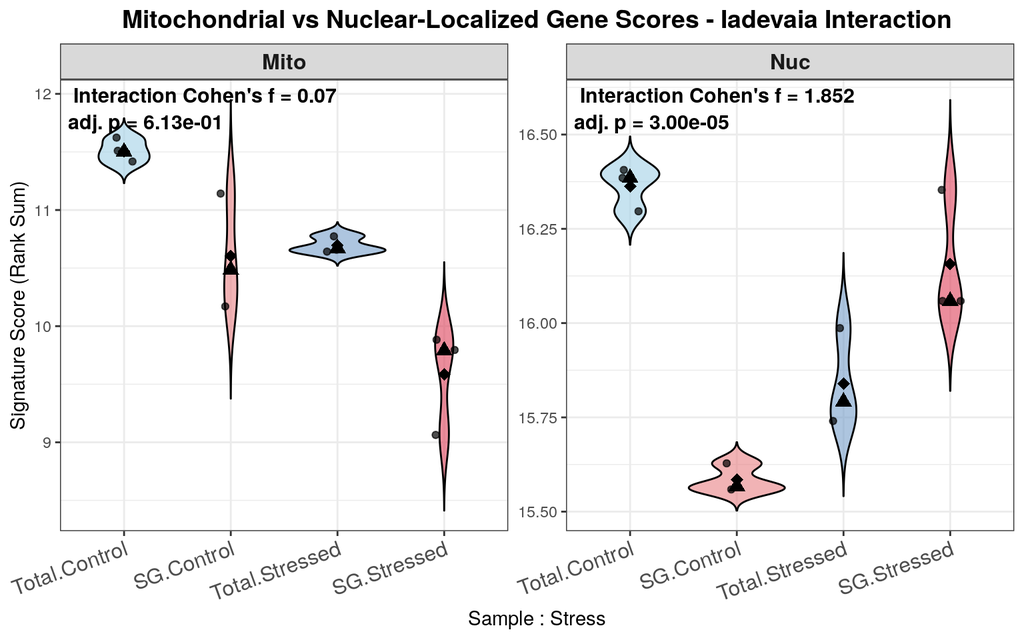

```r
vilsigplot
```

## Volcano Plot with Gene Length

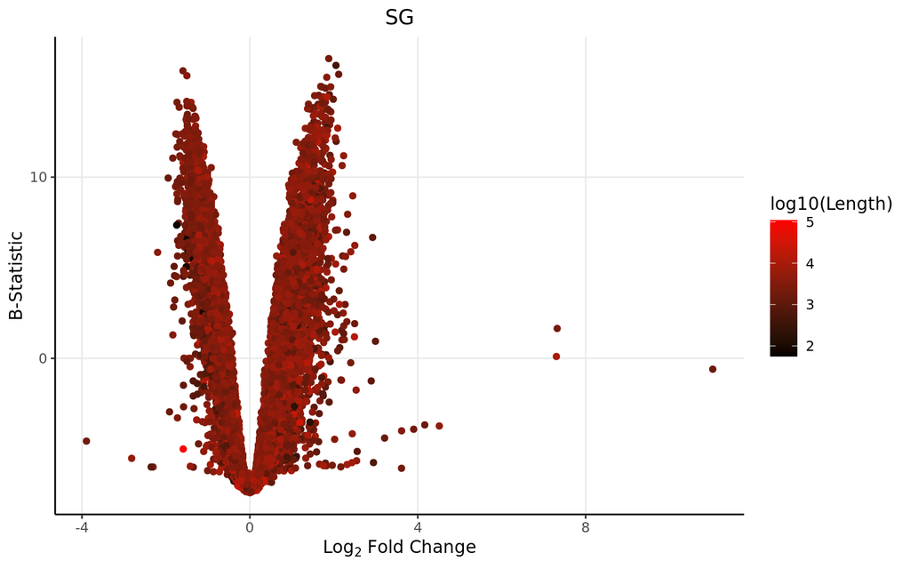

```r
DEGenes_SG$Gene <- row.names(DEGenes_SG)
colnames(genelength) <- c("Length","Gene")
DEGenes_SG <- merge(DEGenes_SG, genelength, by="Gene")

ggplot(data=DEGenes_SG,
                 aes(x=logFC,
                     y=  B)) +
  geom_point(aes(color=log10(Length)))+
  theme_bw() +
  theme(axis.line = element_line(colour = "black"),
        panel.grid.minor = element_blank(),
        panel.border = element_blank(),
        panel.background = element_blank()) +
  ggtitle("SG")+ xlab(expression(Log[2] ~ Fold ~ Change)) + ylab("B-Statistic") +
  theme(plot.title = element_text(hjust = 0.5))  +
  scale_colour_gradient(low = "black", high = "red")+ theme(text=element_text(family = "Quicksand"))
```

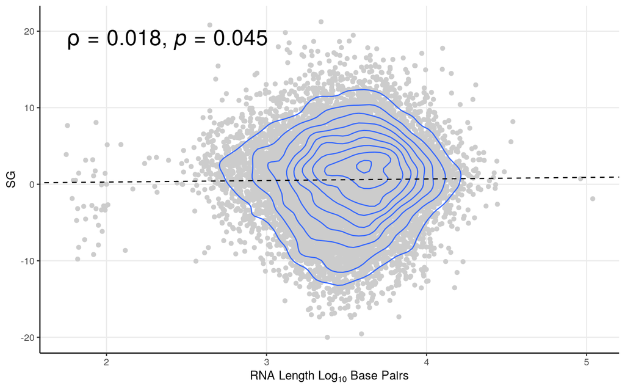

```r
smooth.SG <- lm(t~log10(Length), DEGenes_SG)
liner.SG <- rstandard(smooth.SG)
DEGenes_SG <-cbind(DEGenes_SG, liner.SG)
colnames(DEGenes_SG)[11] <- "Residuals"
row.names(DEGenes_SG) <- DEGenes_SG$Gene
linemarkers <- as.data.frame(DEGenes_SG[abs(DEGenes_SG$Residuals)>4,])

# Calculate the Spearman correlation coefficient
spearman_corr <- cor(DEGenes_SG$t, log10(DEGenes_SG$Length), method = "spearman")



ggplot(DEGenes_SG, aes(y=t, x=log10(Length))) + geom_point(color="#CCCCCC", alpha=1) +   theme_bw()+ geom_density_2d()+
 ylab("SG") + xlab(expression(RNA ~ Length ~ Log[10] ~ Base ~ Pairs)) +
  theme(axis.line = element_line(colour = "black"),
        panel.grid.minor = element_blank(),
        panel.border = element_blank(),
        panel.background = element_blank()) +
  theme(plot.title = element_text(hjust = 0.5))  +
  geom_abline(slope=smooth.SG$coefficients[2], intercept = smooth.SG$coefficients[1], linetype = "dashed")+ stat_cor(method = "spearman", cor.coef.name = "rho",size=7)
```

Controlled SGs show no lenght bias.

## GSEA Enrichment

Now that we have our genes of interest, it would also be interesting to see what are the **altered gene sets** between upregulated and downregulated transcripts from the above comparison. Therefore, lets perform a *Gene Set Enrichment Analysis*

```r
#for all genes
DEGenes_SG <- DEGenes_SG[order(DEGenes_SG[,4]),]
gseatool <- DEGenes_SG[,4]
gseatool <- as.data.frame(gseatool)
colnames(gseatool)[1] <- "t"
gseatool[,2] <- DEGenes_SG$Gene
colnames(gseatool)[2] <- "Symbol"
gseatool <- gseatool[,c(2,1)]

vectorranks <- gseatool$t
names(vectorranks) <- gseatool$Symbol


#to load our pathways
hallmarks.gs <- msigdbr(species = "Homo sapiens", collection =  "H")

hallmarks.gsets <- hallmarks.gs %>% split(x = .$gene_symbol, f = .$gs_name)

for (set in names(hallmarks.gsets)){
  hallmarks.gsets[[set]] <- toupper(hallmarks.gsets[[set]])
}

hallmarks.res <- fgsea(pathways = hallmarks.gsets,
                       stats = vectorranks)
```

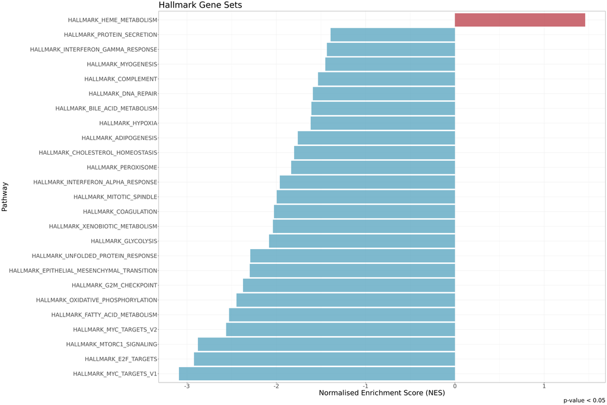

```r
hallmarks.res.tidy <- hallmarks.res %>%
  as_tibble() %>%
  arrange(desc(NES))

hallmarks.res.tidy %>%
  dplyr::select(-leadingEdge, -ES) %>%
  arrange(padj)

hallmark.sg.t <- hallmarks.res.tidy[,c(1,3,6)]
hallmark.sg.t <- as.data.frame(hallmark.sg.t)

#this small part is generic
thresh <- 0.05

#this one is no longer generic
data_to_plot <- hallmarks.res.tidy %>% filter(padj < thresh)

statvec <- c()
for (i in 1:nrow(data_to_plot)){
  if (data_to_plot[i,6] > 0){
    status <- "Upregulated"
  }
 else {
   status <- "Downregulated"
 }
statvec <- c(statvec, status)
}

data_to_plot$Status <- statvec

##-----HALMARK-----
gsea_plot_hall <- ggplot(data_to_plot, aes(reorder(pathway, NES), NES)) +
  geom_col(aes(fill= Status), alpha=0.75) + scale_fill_manual(values = c("#53A2BE","#BA3B46"), name = "Regulation Status", labels = c("Downregulated", "Upregulated"), breaks = c("Downregulated", "Upregulated")) +
  coord_flip() +
  labs(x="Pathway", y="Normalised Enrichment Score (NES)",
       title= "Hallmark Gene Sets",
       caption = paste0("p-value < ", thresh)) + theme(plot.title = element_text(hjust = 1)) +
  theme_bw() + theme(text=element_text(family = "Quicksand")) + theme(legend.position = "none")


gsea_plot_hall+
  theme(text=element_text(size=25,  family="Arial MS"))
```

### For Mito

```r
# --- Rank genes by t-statistic as usual ---
DEGenes_SG <- DEGenes_SG[order(DEGenes_SG[,4]),]
gseatool <- DEGenes_SG[,4]
gseatool <- as.data.frame(gseatool)
colnames(gseatool)[1] <- "t"
gseatool[,2] <- row.names(DEGenes_SG)
colnames(gseatool)[2] <- "Symbol"
gseatool <- gseatool[,c(2,1)]
vectorranks <- gseatool$t
names(vectorranks) <- gseatool$Symbol

# --- Define MitoGenes as a custom gene set ---
MitoGenes <- fread("~/MitoGenes.txt")[[1]]
custom.gsets <- list(MitoGenes = toupper(MitoGenes))

# --- Run fgsea ---
mito.res <- fgsea(pathways = custom.gsets,
                  stats = vectorranks)
```

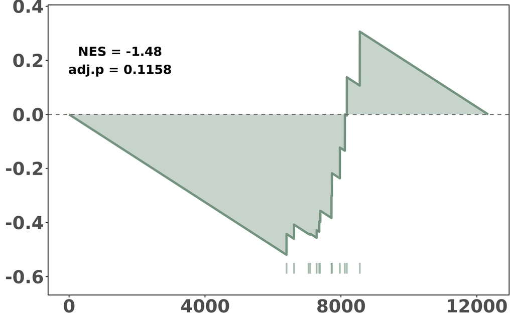

```r
mito.plot.base <- plotEnrichment(custom.gsets[["MitoGenes"]], vectorranks)
curve.data <- mito.plot.base$data

# --- key fix: match the curve's internal descending order ---
ord <- order(vectorranks, decreasing = TRUE)
ranked.names <- names(vectorranks)[ord]
gene.positions <- which(ranked.names %in% custom.gsets[["MitoGenes"]])

rug.top    <- min(curve.data$y) - 0.03
rug.bottom <- rug.top - 0.04

y.min <- rug.bottom - 0.03
y.max <- max(curve.data$y) + 0.05

(mito.plot <- ggplot(curve.data, aes(x = x, y = y)) +
  geom_area(fill = "#73937E", alpha = 0.4) +
  geom_line(color = "#73937E", linewidth = 1.2) +
  geom_hline(yintercept = 0, linetype = "dashed", color = "grey40") +
  geom_segment(data = data.frame(x = gene.positions),
               aes(x = x, xend = x, y = rug.top, yend = rug.bottom),
               color = "#73937E", alpha = 0.6, linewidth = 0.9,
               inherit.aes = FALSE) +
  annotate("text", x = 1500, y = 0.2,
           label = paste0("NES = ", round(mito.res$NES, 2),
                          "\nadj.p = ", round(mito.res$padj, 4)),
           size = 5, family = "Arial MS", fontface = "bold") +
  coord_cartesian(ylim = c(y.min, y.max), clip = "off") +
  theme_bw() +
  theme(text = element_text(size = 25, family = "Arial MS"),
        plot.title = element_text(hjust = 0.5, face = "bold"),
        axis.title = element_blank(),
        axis.text = element_text(face = "bold"),
        panel.grid.minor = element_blank(),
        panel.grid.major = element_blank()))
```

```r
png("~/Projects/StressGranules/SGPAPER/Images/PNG/MitoGSEA_Iade.png", width=7, height=6, units="in", res=300)
mito.plot
dev.off()
```

## GSEA Length

Now, since SGs are enriched for longer transcripts, these pathways may simply be the ones which are tipically enriched in longer transcripts. Therefore, I will repeat the analysis, but using transcript lenght instead of t-statistic.

```r
#for all genes
DEGenes_SG <- DEGenes_SG[order(DEGenes_SG[,8]),]
gseatool <- DEGenes_SG[,8]
gseatool <- as.data.frame(gseatool)
colnames(gseatool)[1] <- "t"
gseatool[,2] <- DEGenes_SG$Gene
colnames(gseatool)[2] <- "Symbol"
gseatool <- gseatool[,c(2,1)]

#for only the genes without the contamination


vectorranks <- log10(gseatool$t)
vectorranks <- scale(vectorranks)
names(vectorranks) <- gseatool$Symbol


#to load our pathways

##-----HALLMARK-----
hallmarks.gs <- msigdbr(species = "Homo sapiens", collection = "H")

hallmarks.gsets <- hallmarks.gs %>% split(x = .$gene_symbol, f = .$gs_name)

for (set in names(hallmarks.gsets)){
  hallmarks.gsets[[set]] <- toupper(hallmarks.gsets[[set]])
}

hallmarks.res <- fgsea(pathways = hallmarks.gsets,
                       stats = vectorranks)
```

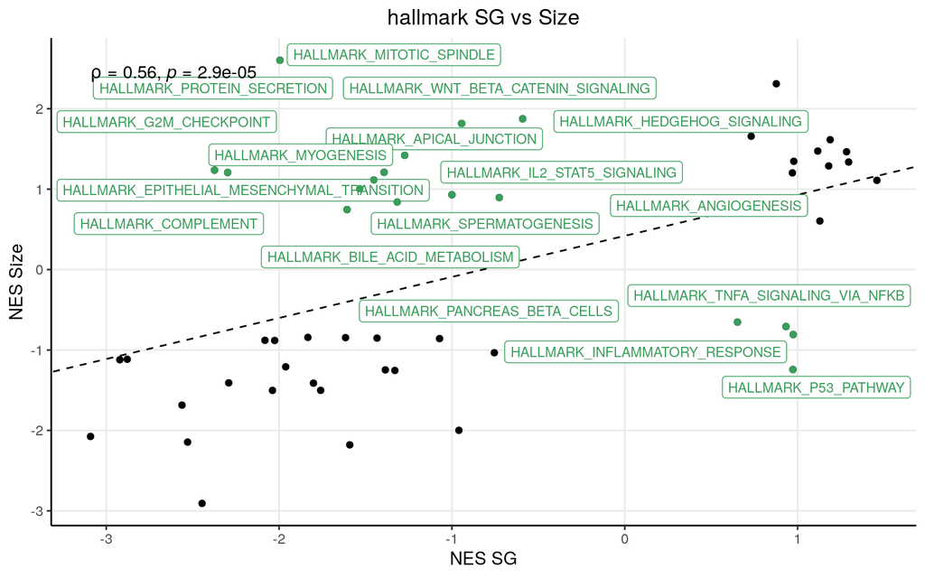

```r
hallmarks.res.tidy <- hallmarks.res %>%
  as_tibble() %>%
  arrange(desc(NES))

hallmarks.res.tidy %>%
  dplyr::select(-leadingEdge, -ES) %>%
  arrange(padj)

hallmark.size.t <- hallmarks.res.tidy[,c(1,3,6)]
hallmark.size.t <- as.data.frame(hallmark.size.t)

#HALLMARK
hallmark.scatter_ak <- merge(hallmark.sg.t, hallmark.size.t, by="pathway")
colnames(hallmark.scatter_ak) <- c("pathway", "sg_pval", "sg", "size_pval", "size")
hallmark.scatter_ak <- na.omit(hallmark.scatter_ak)
res_hallmark <- lm(size ~ sg, hallmark.scatter_ak)

vip.pathways_ak <- as.data.frame(hallmark.scatter_ak[(hallmark.scatter_ak$sg/hallmark.scatter_ak$size)<0,] )



ggplot(hallmark.scatter_ak, aes(x=sg, y=size)) + geom_point(color="black", alpha=01) +   theme_bw()+
 xlab("NES SG") + ylab("NES Size") +
  theme(axis.line = element_line(colour = "black"),
        panel.grid.minor = element_blank(),
        panel.border = element_blank(),
        panel.background = element_blank()) + ggtitle("hallmark SG vs Size")+
  theme(plot.title = element_text(hjust = 0.5)) +
  geom_abline(slope=res_hallmark$coefficients[2], intercept = res_hallmark$coefficients[1], linetype = "dashed") +
  geom_label_repel(vip.pathways_ak[1:ndegs,] , mapping=aes(label=vip.pathways_ak$pathway[1:ndegs]),size=3,point.padding=-0.5, color="#399e5a",max.overlaps = 200)+
  geom_point(data=vip.pathways_ak, aes(x=sg, y= size), color="#399e5a") + stat_cor(method = "spearman", cor.coef.name = "rho")
```

Even though Controlled SGs show no lenght bias, their gene set enrichment is still driven by transcript lenght.

# After SpinSim v.2.

After my SpinSim pipeline, this is how I compared these simulated SGs with bulk and their original counterparts. For more details on this pipeline, please refer to its corresponding files in the Simulations/ folder in the GitHub repository.

```r
read.counts$Gene <- row.names(read.counts)

#To maintain equitable read depth, I base my final total count number per sample on the original samples
goalsum_SG1 <- sum(read.counts$SGs_3_T)
goalsum_SG2 <- sum(read.counts$SGs_6_T)
goalsum_SG3 <- sum(read.counts$SGs_9_T)
goalsum_SG4 <- sum(read.counts$SGs_1_C)
goalsum_SG5 <- sum(read.counts$SGs_4_C)
goalsum_SG6 <- sum(read.counts$SGs_7_C)

#For the simulated samples.
sim_sg1 <- read.table("~/Projects/StressGranules/Simulator/SimulatedSamples/Iade/SIM_IadeBulk_1.txt", sep = ",", header = T)[,c(1,3)]
sim_sg1 <- na.omit(sim_sg1)
colnames(sim_sg1) <- c("Gene", "SimSG1")
sim_sg2 <- read.table("~/Projects/StressGranules/Simulator/SimulatedSamples/Iade/SIM_IadeBulk_2.txt", sep = ",", header = T)[,c(1,3)]
sim_sg2 <- na.omit(sim_sg2)
colnames(sim_sg2) <- c("Gene", "SimSG2")
sim_sg3 <- read.table("~/Projects/StressGranules/Simulator/SimulatedSamples/Iade/SIM_IadeBulk_3.txt", sep = ",", header = T)[,c(1,3)]
sim_sg3 <- na.omit(sim_sg3)
colnames(sim_sg3) <- c("Gene", "SimSG3")
sim_sg4 <- read.table("~/Projects/StressGranules/Simulator/SimulatedSamples/Iade/SIM_IadeBulk_4.txt", sep = ",", header = T)[,c(1,3)]
sim_sg4 <- na.omit(sim_sg4)
colnames(sim_sg4) <- c("Gene", "SimSG4")
sim_sg5 <- read.table("~/Projects/StressGranules/Simulator/SimulatedSamples/Iade/SIM_IadeBulk_5.txt", sep = ",", header = T)[,c(1,3)]
sim_sg5 <- na.omit(sim_sg5)
colnames(sim_sg5) <- c("Gene", "SimSG5")
sim_sg6 <- read.table("~/Projects/StressGranules/Simulator/SimulatedSamples/Iade/SIM_IadeBulk_6.txt", sep = ",", header = T)[,c(1,3)]
sim_sg6 <- na.omit(sim_sg6)
colnames(sim_sg6) <- c("Gene", "SimSG6")

#merging old samples up
simsamples <- merge(sim_sg1, sim_sg2, by="Gene")
simsamples <- merge(simsamples, sim_sg3, by="Gene")
simsamples <- merge(simsamples, sim_sg4, by="Gene")
simsamples <- merge(simsamples, sim_sg5, by="Gene")
simsamples <- merge(simsamples, sim_sg6, by="Gene")
simsamples <- merge(simsamples, genelength[,1:2], by="Gene")

#De-Tpming old samples
simsamples$Counts_SimSG1 <- simsamples$SimSG1*simsamples$Length
simsamples$Counts_SimSG1 <- simsamples$Counts_SimSG1/sum(simsamples$Counts_SimSG1)*goalsum_SG1
simsamples$Counts_SimSG2 <- simsamples$SimSG2*simsamples$Length
simsamples$Counts_SimSG2 <- simsamples$Counts_SimSG2/sum(simsamples$Counts_SimSG2)*goalsum_SG2
simsamples$Counts_SimSG3 <- simsamples$SimSG3*simsamples$Length
simsamples$Counts_SimSG3 <- simsamples$Counts_SimSG3/sum(simsamples$Counts_SimSG3)*goalsum_SG3
simsamples$Counts_SimSG4 <- simsamples$SimSG4*simsamples$Length
simsamples$Counts_SimSG4 <- simsamples$Counts_SimSG4/sum(simsamples$Counts_SimSG4)*goalsum_SG4
simsamples$Counts_SimSG5 <- simsamples$SimSG5*simsamples$Length
simsamples$Counts_SimSG5 <- simsamples$Counts_SimSG5/sum(simsamples$Counts_SimSG5)*goalsum_SG5
simsamples$Counts_SimSG6 <- simsamples$SimSG6*simsamples$Length
simsamples$Counts_SimSG6 <- simsamples$Counts_SimSG6/sum(simsamples$Counts_SimSG6)*goalsum_SG6
print(names(simsamples))  # run this once just to see what's actually in there
```

```
##  [1] "Gene"          "SimSG1"        "SimSG2"        "SimSG3"
##  [5] "SimSG4"        "SimSG5"        "SimSG6"        "Length"
##  [9] "Counts_SimSG1" "Counts_SimSG2" "Counts_SimSG3" "Counts_SimSG4"
## [13] "Counts_SimSG5" "Counts_SimSG6"
```

```r
simsamples <- simsamples[, c("Gene", "Counts_SimSG1", "Counts_SimSG2", "Counts_SimSG3", "Counts_SimSG4", "Counts_SimSG5", "Counts_SimSG6")]

OGsamples <- read.counts[,c(1,3,5,2,4,6,7,9,11,8,10,12)]
OGsamples$Gene <- row.names(OGsamples)

SG_City <- merge(OGsamples, simsamples, by="Gene")
SG_City <- SG_City %>% # If two gene ids resulted in the same gene name, this will sum up their counts
  group_by(Gene) %>%
  summarise(across(everything(), sum, na.rm = TRUE))
SG_City <- as.data.frame(SG_City)
row.names(SG_City) <- SG_City$Gene
SG_City$Gene <- NULL
```

## Filtration

### *Before Filtration*

Let us begin with the filtration.

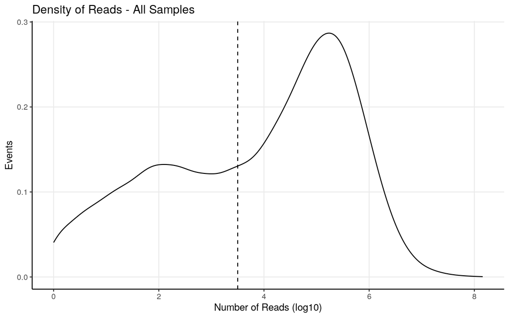

```r
alternew.bu <- log10(rowSums(SG_City[,1:3]))
alternew.bu <- as.data.frame(alternew.bu)

alternew.rsg <- log10(rowSums(SG_City[,4:6]))
alternew.rsg <- as.data.frame(alternew.rsg)

alternew.ssg <- log10(rowSums(SG_City[,7:9]))
alternew.ssg <- as.data.frame(alternew.ssg)

alternew <- log10(rowSums(SG_City))
alternew <- as.data.frame(alternew)

ggplot(alternew, aes(x=alternew)) + geom_density() + theme_bw() + geom_vline(xintercept = 3.5, linetype = "dashed") + ylab("Events") + xlab("Number of Reads (log10)") +
  theme(axis.line = element_line(colour = "black"),
        panel.grid.minor = element_blank(),
        panel.border = element_blank(),
        panel.background = element_blank()) + ggtitle("Density of Reads - All Samples")
```

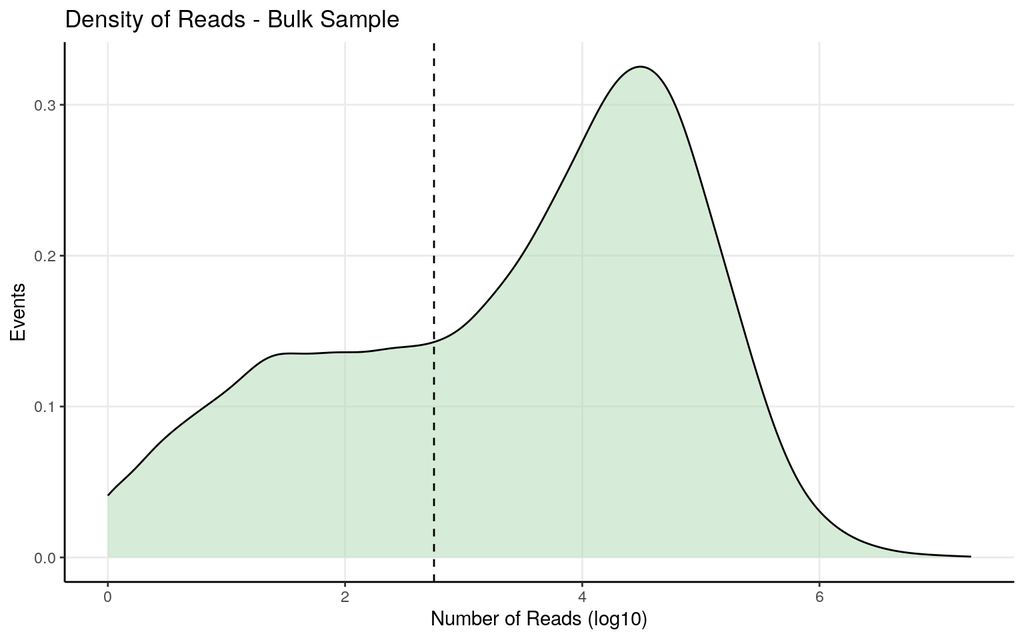

```r
ggplot(alternew.bu, aes(x=alternew.bu)) + geom_density(fill="#B0D9B1", alpha=0.5) + theme_bw() + geom_vline(xintercept = 2.75, linetype = "dashed") + ylab("Events") + xlab("Number of Reads (log10)") +
  theme(axis.line = element_line(colour = "black"),
        panel.grid.minor = element_blank(),
        panel.border = element_blank(),
        panel.background = element_blank()) + ggtitle("Density of Reads - Bulk Sample")
```

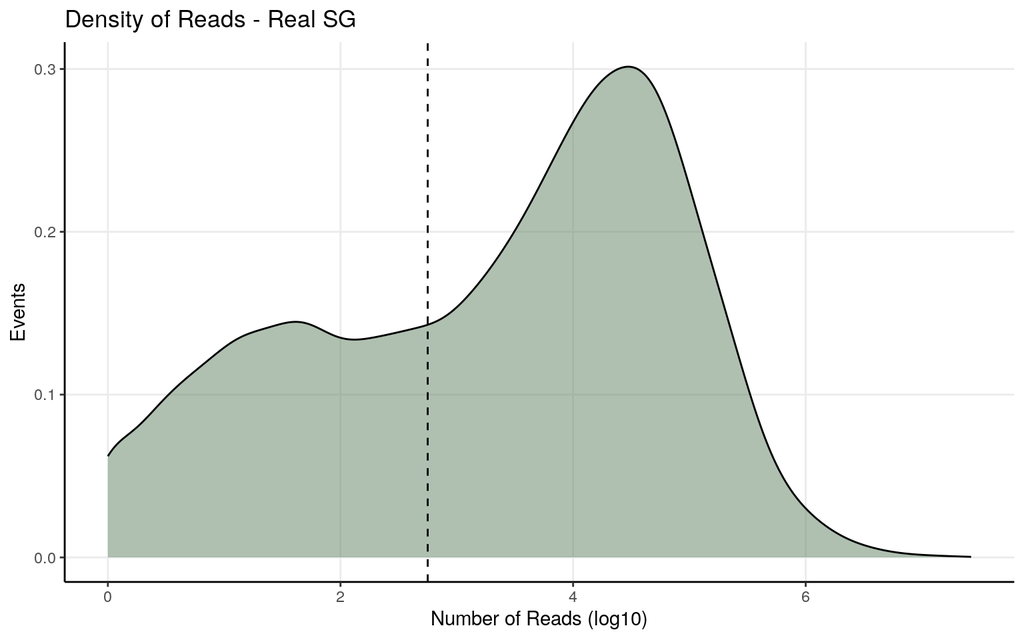

```r
ggplot(alternew.rsg, aes(x=alternew.rsg)) + geom_density(fill="#618264", alpha=0.5) + theme_bw() + geom_vline(xintercept = 2.75, linetype = "dashed") + ylab("Events") + xlab("Number of Reads (log10)") +
  theme(axis.line = element_line(colour = "black"),
        panel.grid.minor = element_blank(),
        panel.border = element_blank(),
        panel.background = element_blank()) + ggtitle("Density of Reads - Real SG")
```

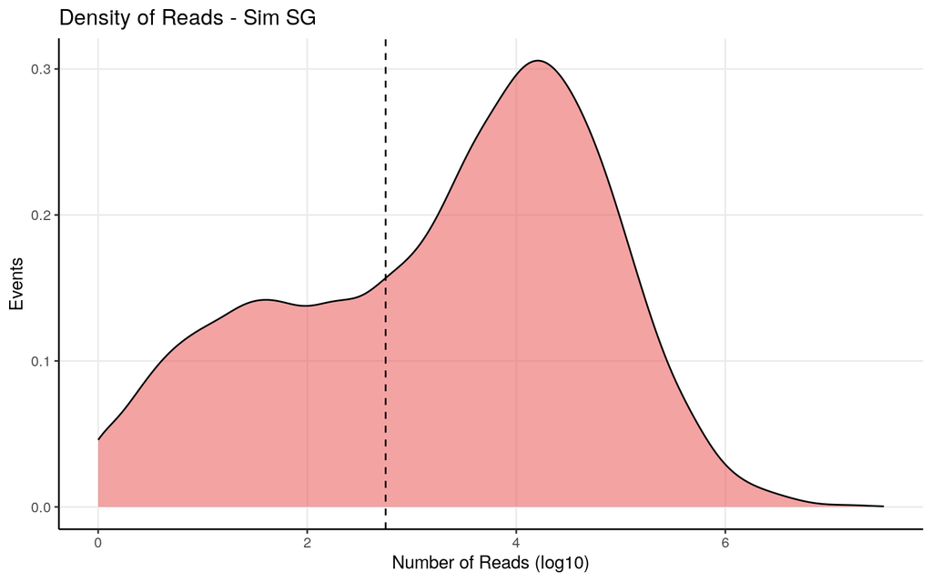

```r
ggplot(alternew.ssg, aes(x=alternew.ssg)) + geom_density(fill="#EA4848", alpha=0.5) + theme_bw() + geom_vline(xintercept = 2.75, linetype = "dashed") + ylab("Events") + xlab("Number of Reads (log10)") +
  theme(axis.line = element_line(colour = "black"),
        panel.grid.minor = element_blank(),
        panel.border = element_blank(),
        panel.background = element_blank()) + ggtitle("Density of Reads - Sim SG")
```

```r
dffordensy <- SG_City
sampy <- c(rep("BUC",3), rep("BUS",3), rep("RSGC",3),rep("RSGS",3), rep("SimSGS",3), rep("SimSGC",3))
names(sampy) <- colnames(dffordensy)
dffordensy <- reshape2::melt(t(dffordensy))
colnames(dffordensy) <- c("Sample", "Gene", "Expression")
```

### *After Filtration*

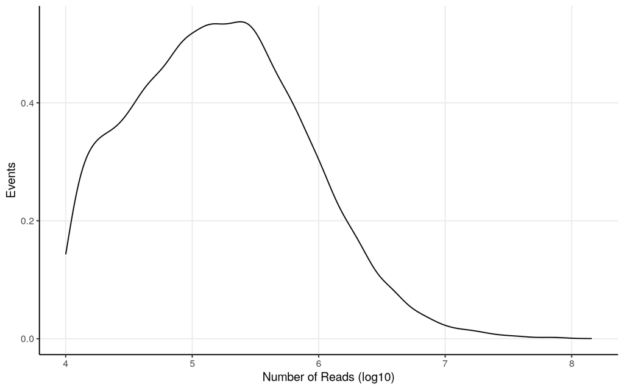

```r
filterednew <- subset(SG_City, alternew>4)
filterednew.bu <- subset(SG_City, alternew.bu>2.75)
filterednew.rsg <- subset(SG_City, alternew.rsg>2.75)
filterednew.ssg <- subset(SG_City, alternew.ssg>2.75)

#after cutting, its a good idea to visualize again
falternew <- log10(rowSums(filterednew))
falternew <- as.data.frame(falternew)
ggplot(falternew, aes(x=falternew)) + geom_density() + theme_bw() + ylab("Events") + xlab("Number of Reads (log10)") +
  theme(axis.line = element_line(colour = "black"),
        panel.grid.minor = element_blank(),
        panel.border = element_blank(),
        panel.background = element_blank())
```

```r
#lets save the genes which we maintain
impgenes <- row.names(falternew)
impgenes.bu <- c(row.names(filterednew.bu))
impgenes.rsg <- c(row.names(filterednew.rsg))
impgenes.ssg <- c(row.names(filterednew.ssg))

#Now we need to select only the rows which have those genes.
finaltable <- SG_City[row.names(SG_City)%in%impgenes,]
#finaltable <- finaltable[row.names(finaltable)%in%impgenes.bu,]
#finaltable <- finaltable[row.names(finaltable)%in%impgenes.rsg,]
#finaltable <- finaltable[row.names(finaltable)%in%impgenes.ssg,]
```

## Matrices

Good! Now we can proceed by designing our matrices.

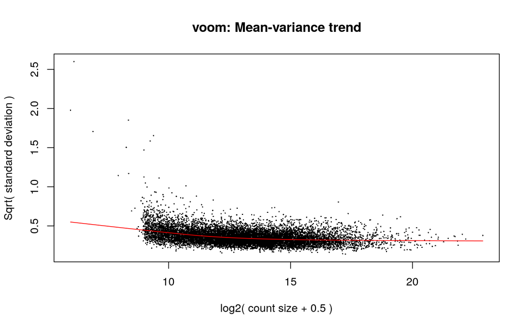

```r
#To be able to use Voom, we must first convert our read count table into a special DGE object.
D0 <- DGEList(finaltable)

#Then we calculate the normalization factors.
#Bear in mind this step calculates the normalization factors, but does not normalize itself.
D0 <- calcNormFactors(D0)


#Now we do our matrix itself
mm <- model.matrix(~0+sampy)

#and now we normalize. This step also turns our counts into log2-counts per million.
y <- voom(D0, mm, plot = T)
```

## Normalisation

For normalisation I convert the read counts into log2CPMs. Its a good way to visualize how the reads are.

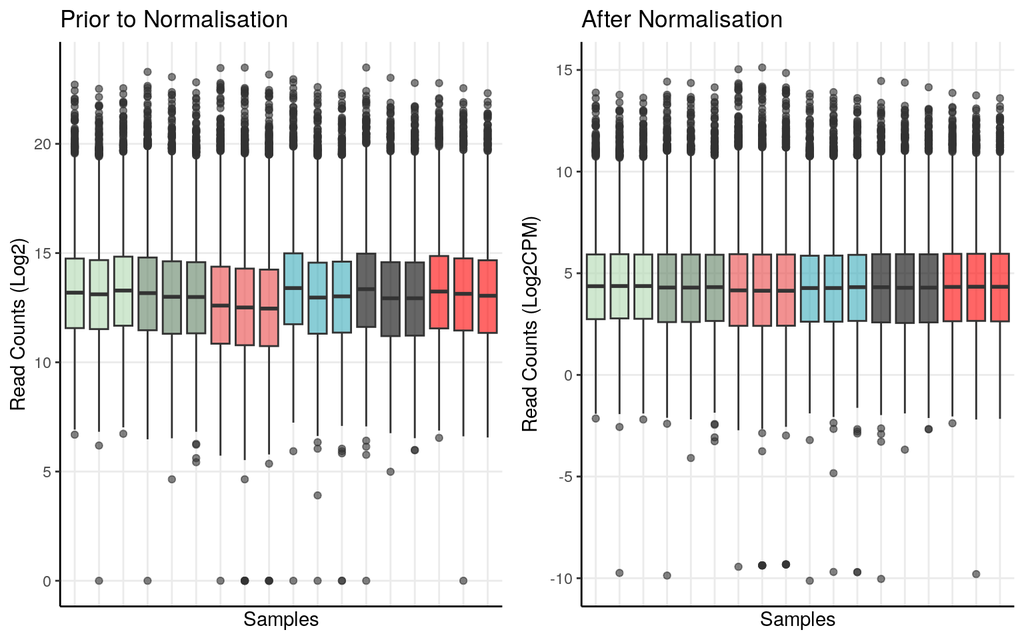

```r
dfforboxy <- finaltable
coolors <-c("#B0D9B1", "#B0D9B1", "#B0D9B1", "#618264", "#618264", "#618264", "#EA4848", "#EA4848", "#EA4848", "#3BABBA", "#3BABBA", "#3BABBA", "black", "red")


orderforplots <- sampy
colouring <- data.frame(Sample=colnames(dfforboxy), Types=orderforplots)
dfforboxy <- reshape2::melt(dfforboxy)
colnames(dfforboxy) <- c("Sample", "Expression")
dfforboxy <- merge(dfforboxy, colouring, by="Sample")
prenorm <- ggplot(dfforboxy, aes(x=Sample, y=(log2(Expression+1)), fill=Types)) + geom_boxplot(alpha=0.6) + theme_bw() + ylab("Read Counts (Log2)") + xlab("Samples") + scale_fill_manual(name = "Sample Type", values = unique(coolors), labels=unique(sampy), breaks =unique(sampy)) +
  theme(axis.line = element_line(colour = "black"),
        panel.grid.minor = element_blank(),
        panel.border = element_blank(),
        panel.background = element_blank(),
        axis.text.x=element_blank(),
        axis.ticks.x=element_blank(),
        legend.position = "None") + ggtitle("Prior to Normalisation")

dfforboxy <- y$E
dfforboxy <- reshape2::melt(dfforboxy)
dfforboxy <- dfforboxy[,-1]
colnames(dfforboxy) <- c("Sample", "Expression")
dfforboxy <- merge(dfforboxy, colouring, by="Sample")
postnorm <- ggplot(dfforboxy, aes(x=Sample, y=Expression, fill=Types)) + geom_boxplot(alpha=0.6) + theme_bw() + ylab("Read Counts (Log2CPM)") + xlab("Samples") + scale_fill_manual(name = "Sample Type", values = unique(coolors), labels=unique(sampy), breaks =unique(sampy)) +
  theme(axis.line = element_line(colour = "black"),
        panel.grid.minor = element_blank(),
        panel.border = element_blank(),
        panel.background = element_blank(),
        axis.text.x=element_blank(),
        axis.ticks.x=element_blank(),
        legend.position = "None") + ggtitle("After Normalisation")

ggarrange(prenorm, postnorm, nrow=1)
```

## PCA

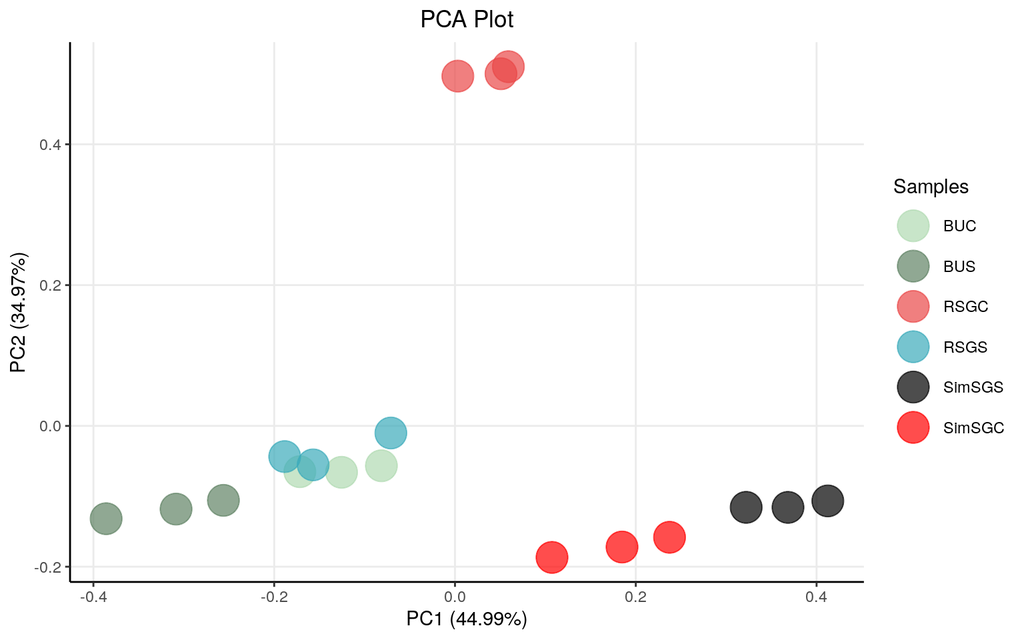

```r
#this is done to be able to do traditional PCA
dfforpca <- y$E
dfforpca <- rbind(dfforpca, sampy)
row.names(dfforpca)[nrow(dfforpca)] <- "sampy"
dfforpca <- t(dfforpca)
numcol <- c(1:(ncol(dfforpca)-1))
dfforpca <- as.data.frame(dfforpca) #for some reason I can only change colum type if its a dataframe

dfforpca[ ,numcol] <- apply(dfforpca[ , numcol], 2,            # to turn our columns into numeric
                            function(x) as.numeric(as.character(x)))

#sapply(dfforpca, class) #to check class

# Or specify the factor levels in the order you want
dfforpca$forall <- factor(dfforpca$sampy, levels = unique(sampy))

pca_res <- prcomp(dfforpca[,numcol], scale=FALSE) #prepare the pca

#to make everything pretty
p <- autoplot(pca_res, data = dfforpca, x=1, y=2, colour = "sampy", size=8, alpha=0.7)
p <- p + theme_bw() + scale_colour_manual((name = "Samples"), values = unique(coolors), labels=unique(sampy))
p <- p + ggtitle("PCA Plot") + theme(plot.title = element_text(hjust = 0.5)) +
  theme(axis.line = element_line(colour = "black"),
        panel.grid.minor = element_blank(),
        panel.border = element_blank(),
        panel.background = element_blank())
p
```

```r
#in case you want to see them yourself
contribs1 <- pca_res$rotation[,1]
contribs2 <- pca_res$rotation[,2]

#These are the biggest contributors to the PCA1 (right side)
(pos1genes <- sort(contribs1, decreasing=T)[1:10])
```

```
##        TTN   KCNQ1OT1      NEAT1      OBSCN     GRIN2B      FLRT2      KMT2D
## 0.05714370 0.05508759 0.03662306 0.03515288 0.03260751 0.03138038 0.03132871
##      LRRC7        NEB    RPS6KA5
## 0.03008727 0.02999144 0.02996195
```

```r
#These are the biggest contributors to the PCA1 (left side)
(neg1genes <- sort(contribs1, decreasing=F)[1:10])
```

```
##     MIR7705      MIR611      MIR762     MIR1282     SNORD86     MIR4709
## -0.04092102 -0.03787016 -0.03718088 -0.03691371 -0.03678931 -0.03662765
##     MIR4721   MIR1244-1     MIR6728     MIR3917
## -0.03650925 -0.03624319 -0.03556322 -0.03548150
```

```r
#These are the biggest contributors to the PCA2 (up side)
(pos2genes <- sort(contribs2, decreasing=T)[1:10])
```

```
##       PLD4    MIR6728  MORC2-AS1 MYCBP2-AS1 COL4A2-AS1       MRAP      NOXO1
## 0.03803519 0.03446708 0.03433869 0.03176603 0.03156448 0.03105073 0.02958251
##    MIR3652    MSANTD1    EZR-AS1
## 0.02873771 0.02724636 0.02705634
```

```r
#These are the biggest contributors to the PCA2 (down side)
(neg2genes <- sort(contribs2, decreasing=F)[1:10])
```

```
##       KCNQ2      MAPK10       NRXN1         KIT     TTN-AS1         TTN
## -0.09660608 -0.05439217 -0.04965116 -0.04641674 -0.04292544 -0.04260601
##   MUC20-OT1         ALK     BMS1P14      NECAB1
## -0.04161809 -0.04026436 -0.03817011 -0.03773571
```

## Linear Models

Now we must perform linear model fitting. Although we can perform several comparisons, which I leave the contrasts off here, I will focus on the comparison of the Simulated SGs with the Original SGs, as this is what reveals what is more or less enriched than what would be expected with centrifugation alone.

```r
fitted <- lmFit(y, mm)

head(coef(fitted))
```

```
##          sampyBUC sampyBUS sampyRSGC sampyRSGS sampySimSGC sampySimSGS
## A1BG     2.472332 3.050865 0.9647031  2.205998   2.4153871   3.0378941
## A1BG-AS1 1.512476 1.025578 1.4246987  1.257924   0.8754568   0.4238947
## A2M      2.222765 2.291233 3.3552577  2.436022   2.4768220   2.5880105
## AAAS     7.691610 7.846523 8.6724653  7.705429   7.0214004   7.2174835
## AACS     5.126079 5.227458 6.2161631  5.432577   5.0280260   5.1704611
## AADAT    3.180757 3.196098 2.4133219  3.015532   2.7172552   2.7742057
```

```r
#_____________________Original Enrichment
#next we measure contrasts between groups (log-fold change is obtained from these fitted linear models)
contr <- makeContrasts(sampyRSGS  - sampyBUS, levels = colnames(coef(fitted)))

#next we estimate the contrast for each gene
tmp <- contrasts.fit(fitted, contr)


#use empirical bayes smoothing of standard erros (shrinks extreme standard erros)
tmp <- eBayes(tmp)

top.table <- topTable(tmp, sort.by = "logFC", n = Inf)

DEGenes <- top.table

originalenrichment <- data.frame(Gene=row.names(DEGenes), og_t=DEGenes$t, og_logFC=DEGenes$logFC)

#_____________________Simulated Enrichment
#next we measure contrasts between groups (log-fold change is obtained from these fitted linear models)
contr <- makeContrasts(sampySimSGS  - sampyBUS, levels = colnames(coef(fitted)))

#next we estimate the contrast for each gene
tmp <- contrasts.fit(fitted, contr)


#use empirical bayes smoothing of standard erros (shrinks extreme standard erros)
tmp <- eBayes(tmp)

top.table <- topTable(tmp, sort.by = "logFC", n = Inf)

DEGenes <- top.table

simulatedenrichment <- data.frame(Gene=row.names(DEGenes), sim_t=DEGenes$t, sim_logFC=DEGenes$logFC)

#_____________________Corrected Enrichment
#next we measure contrasts between groups (log-fold change is obtained from these fitted linear models)
contr <- makeContrasts(sampyRSGS  - sampySimSGS, levels = colnames(coef(fitted)))

#next we estimate the contrast for each gene
tmp <- contrasts.fit(fitted, contr)


#use empirical bayes smoothing of standard erros (shrinks extreme standard erros)
tmp <- eBayes(tmp)

top.table <- topTable(tmp, sort.by = "logFC", n = Inf)

DEGenes <- top.table



ndegs <- 20
```

## Original SG vs Simulated SG

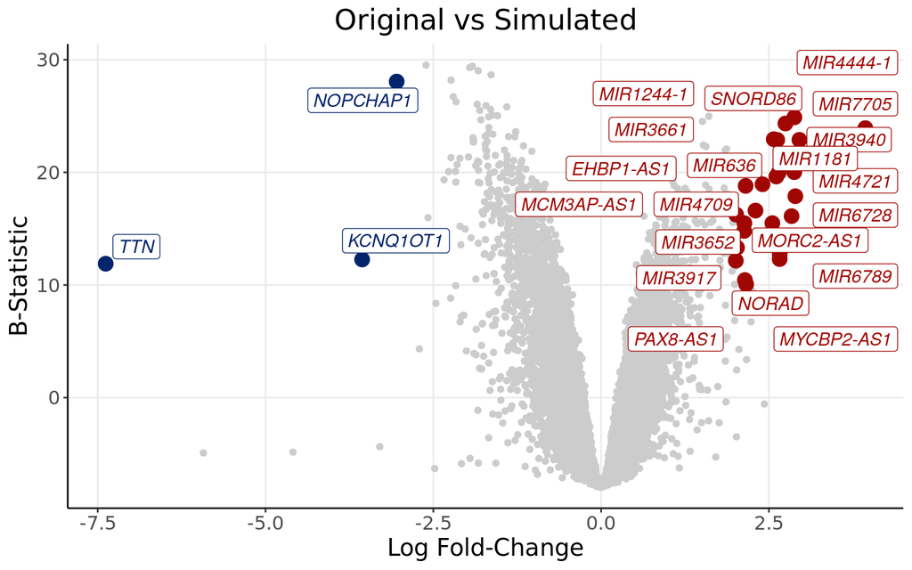

```r
#write.table(x = DEGenes,
#            file = "~/Projects/StressGranules/SGPAPER/RealSGs/RealvIadevaia.txt", sep="\t", #col.names = TRUE, row.names = TRUE, quote=FALSE)


upmarkers <- as.data.frame(DEGenes[DEGenes$logFC>2 & DEGenes$B>10,] )
downmarkers <- as.data.frame(DEGenes[DEGenes$logFC< -3 & DEGenes$B>10,] )

ggplot(data=DEGenes,
                 aes(x=logFC,
                     y=  B)) +
  geom_point(color="#CCCCCC")+
  theme_bw() + ylab("B-Statistic")+xlab("Log Fold-Change")+
  theme(axis.line = element_line(colour = "black"),
        panel.grid.minor = element_blank(),
        panel.border = element_blank(),
        panel.background = element_blank()) +
  ggtitle("Original vs Simulated")+
  theme(plot.title = element_text(hjust = 0.5), plot.subtitle = element_text(hjust = 0.5))  +
  geom_point(data=upmarkers, aes(x=logFC, y=  B), color="#A10702",size=4)+
  geom_point(data=downmarkers, aes(x=logFC, y=  B), color="#03256C",size=4) +
  geom_label_repel(upmarkers[1:ndegs,] , mapping=aes(label=row.names(upmarkers)[1:ndegs]),size=4,point.padding=-0.5, color="#A10702",max.overlaps = 20, fontface="italic")+
  geom_label_repel(downmarkers[1:ndegs,] , mapping=aes(label=row.names(downmarkers)[1:ndegs]),size=4,point.padding=-0.5, color="#03256C",max.overlaps = 20, fontface="italic")+
  theme(text=element_text(size=15,  family="Arial MS"))
```

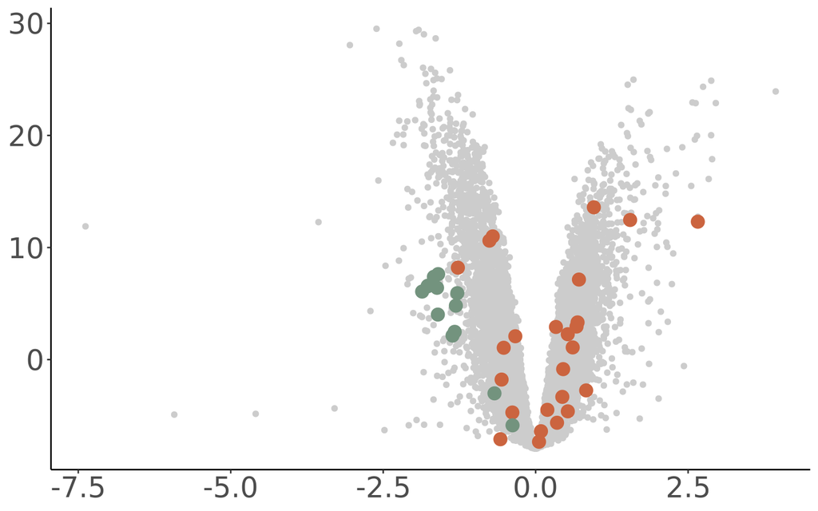

```r
correctedsignal <- data.frame(Gene=row.names(DEGenes), cor_t=DEGenes$t, cor_logFC=DEGenes$logFC)


MitoGenes <- fread("~/MitoGenes.txt")[[1]]
MitoData <- DEGenes[rownames(DEGenes) %in% MitoGenes, ]
NucGenes <- fread("~/rnalocate_mito_filt.csv")[[1]]
NucData <- DEGenes[rownames(DEGenes) %in% NucGenes, ]
(m <- ggplot(data=DEGenes,
                 aes(x=logFC,
                     y=B)) +
  geom_point(color="#CCCCCC") +
  geom_point(data=NucData, aes(x=logFC, y=B), color="#CB643F", size=4) +
  geom_point(data=MitoData, aes(x=logFC, y=B), color="#73937E", size=4) +
  ylab("B-Statistic") +
  xlab(expression(Log[2]~"Fold-Change")) +
  theme(
    axis.line = element_line(colour = "black"),
    panel.grid.major = element_blank(),   # remove major gridlines
    panel.grid.minor = element_blank(),   # remove minor gridlines
    panel.border = element_blank(),
    panel.background = element_blank(),
    axis.title = element_blank()
  ) +
  theme(plot.title = element_text(hjust = 0.5), plot.subtitle = element_text(hjust = 0.5)) +
  theme(text=element_text(size=25, family="Arial MS")))
```

# MA Plot

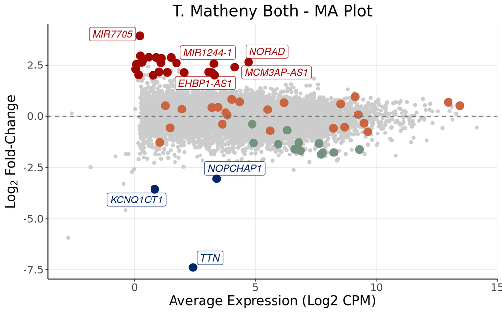

```r
# MA plot: mean expression (x) vs logFC (y), same highlighting scheme as the volcano

ggplot(data=DEGenes,
                 aes(x=AveExpr,
                     y=logFC)) +
  geom_point(color="#CCCCCC") +
  geom_point(data=MitoData, aes(x=AveExpr, y=logFC), color="#73937E", size=4) +
  geom_point(data=NucData, aes(x=AveExpr, y=logFC), color="#CB643F", size=4) +
  geom_hline(yintercept = 0, linetype="dashed", color="grey40") +
  theme_bw() + ylab(expression(Log[2]~"Fold-Change")) + xlab("Average Expression (Log2 CPM)") +
  theme(axis.line = element_line(colour = "black"),
        panel.grid.minor = element_blank(),
        panel.border = element_blank(),
        panel.background = element_blank()) +
  ggtitle("T. Matheny Both - MA Plot") +
  theme(plot.title = element_text(hjust = 0.5), plot.subtitle = element_text(hjust = 0.5)) +
  geom_label_repel(upmarkers[1:ndegs,], mapping=aes(x=AveExpr, y=logFC, label=row.names(upmarkers)[1:ndegs]), size=4, point.padding=-0.5, color="#A10702", max.overlaps=20, fontface="italic") +
  geom_label_repel(downmarkers[1:ndegs,], mapping=aes(x=AveExpr, y=logFC, label=row.names(downmarkers)[1:ndegs]), size=4, point.padding=-0.5, color="#03256C", max.overlaps=20, fontface="italic") +
  geom_point(data=upmarkers, aes(x=AveExpr, y=logFC), color="#A10702", size=4) +
  geom_point(data=downmarkers, aes(x=AveExpr, y=logFC), color="#03256C", size=4) +
  theme(text=element_text(size=15, family="Arial MS"))
```

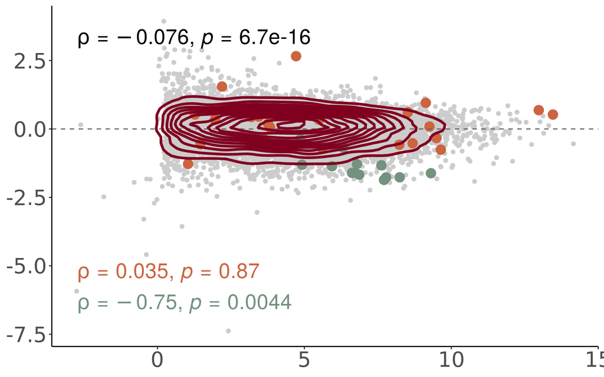

```r
# Publication-style version, stripped of axis titles, matching your "m" plot
(ma <- ggplot(data=DEGenes,
                 aes(x=AveExpr,
                     y=logFC)) +
  geom_point(color="#CCCCCC") +
  geom_point(data=MitoData, aes(x=AveExpr, y=logFC), color="#73937E", size=4) +
  geom_point(data=NucData, aes(x=AveExpr, y=logFC), color="#CB643F", size=4) +
  geom_hline(yintercept = 0, linetype="dashed", color="grey40") +
  ylab(expression(Log[2]~"Fold-Change")) +
  xlab("Average Expression (Log2 CPM)") + geom_density2d(color = "#800020", size = 1.2) + stat_cor(method = "spearman", cor.coef.name = "rho", size=7)+
  stat_cor(data = MitoData, aes(x=AveExpr, y=logFC), method = "spearman",
           cor.coef.name = "rho", size=7, color = "#73937E", label.y.npc = 0.1) +
  stat_cor(data = NucData, aes(x=AveExpr, y=logFC), method = "spearman",
           cor.coef.name = "rho", size=7, color = "#CB643F", label.y.npc = 0.2) +
  theme(
    axis.line = element_line(colour = "black"),
    panel.grid.major = element_blank(),
    panel.grid.minor = element_blank(),
    panel.border = element_blank(),
    panel.background = element_blank(),
    axis.title = element_blank()
  ) +
  theme(plot.title = element_text(hjust = 0.5), plot.subtitle = element_text(hjust = 0.5)) +
  theme(text=element_text(size=25, family="Arial MS")))
```

```r
png("~/Projects/StressGranules/SGPAPER/Images/PNG/IadeMito_MA.png", width = 7, height=6, units = "in", res=300)
ma
dev.off()
```

## MA Plot

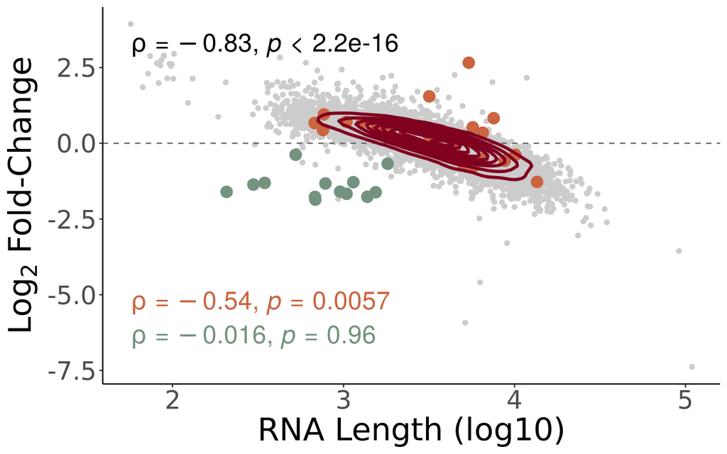

```r
MitoGenes <- fread("~/MitoGenes.txt")[[1]]

genelength <- read.csv("~/Projects/StressGranules/SG_Transcriptome/RP_Data_2021/TrimmedSamples/alignment_STAR/TranscriptLenght.txt", header=T)
genelength <- subset(genelength, Ensembl.Canonical==1)
genelength <- subset(genelength, Gene.name!="")
genelength <- genelength %>%
  group_by(Gene.name) %>%
  slice(which.max(Transcript.length..including.UTRs.and.CDS.)) %>%
  ungroup()
genelength <- genelength[,-c(2,3)]
colnames(genelength) <- c("Length", "Gene")

genelength$Cromo <- ifelse(genelength$Gene %in% MitoGenes, "Mito", "Other")

# Apply the length-based weight formula
genelength$S <- ifelse(
  genelength$Cromo == "Mito",
  (genelength$Length)^(1/3) * 3.23e-11 + 1.17e-9,   # Formula for mitochondrial RNAs
  (genelength$Length)^(1/3) * 6.09e-11 + 3.88e-10    # Formula for other RNAs
)
DEGenes$Gene <- row.names(DEGenes)
DEGenes <- merge(DEGenes, genelength, by="Gene")
MitoGenes <- fread("~/MitoGenes.txt")[[1]]
MitoData <- DEGenes[DEGenes$Gene %in% MitoGenes, ]
NucGenes <- fread("~/rnalocate_mito_filt.csv")[[1]]
NucData <- DEGenes[DEGenes$Gene %in% NucGenes, ]

# Publication-style version, stripped of axis titles, matching your "m" plot
(ma <- ggplot(data=DEGenes,
                 aes(x=log10(Length),
                     y=logFC)) +
  geom_point(color="#CCCCCC") +
  geom_point(data=MitoData, aes(x=log10(Length), y=logFC), color="#73937E", size=4) +
  geom_point(data=NucData, aes(x=log10(Length), y=logFC), color="#CB643F", size=4) +
  geom_hline(yintercept = 0, linetype="dashed", color="grey40") +
  ylab(expression(Log[2]~"Fold-Change")) + geom_density2d(color = "#800020", size = 1.2) + stat_cor(method = "spearman", cor.coef.name = "rho", size=7)+
  stat_cor(data = MitoData, aes(x=log10(Length), y=logFC), method = "spearman",
           cor.coef.name = "rho", size=7, color = "#73937E", label.y.npc = 0.1) +
  stat_cor(data = NucData, aes(x=log10(Length), y=logFC), method = "spearman",
           cor.coef.name = "rho", size=7, color = "#CB643F", label.y.npc = 0.2) +
  xlab("RNA Length (log10)") +
  theme(
    axis.line = element_line(colour = "black"),
    panel.grid.major = element_blank(),
    panel.grid.minor = element_blank(),
    panel.border = element_blank(),
    panel.background = element_blank()
  ) +
  theme(plot.title = element_text(hjust = 0.5), plot.subtitle = element_text(hjust = 0.5)) +
  theme(text=element_text(size=25, family="Arial MS")))
```

```r
png("~/Projects/StressGranules/SGPAPER/Images/PNG/IadeMito_MA_length.png", width = 7, height=6, units = "in", res=300)
ma
dev.off()
```

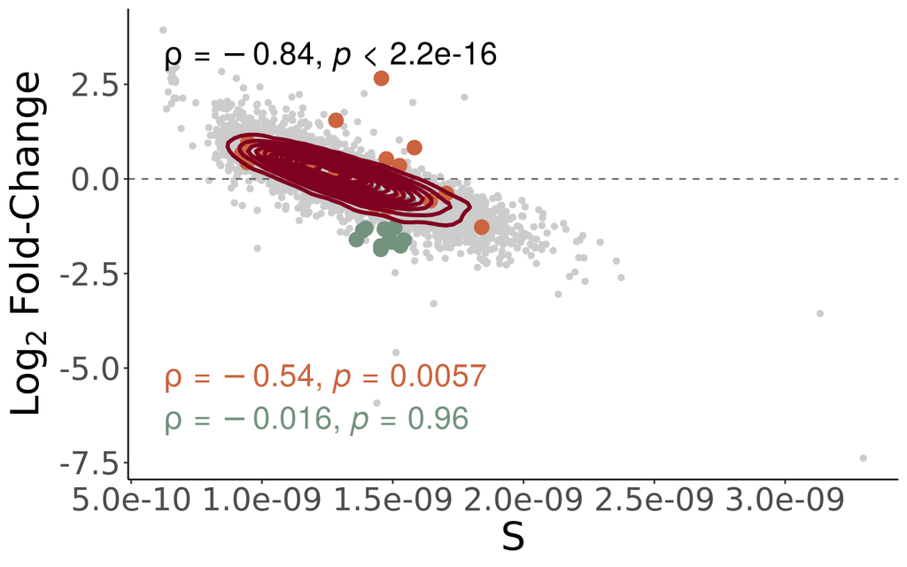

```r
# Publication-style version, stripped of axis titles, matching your "m" plot
(ma <- ggplot(data=DEGenes,
                 aes(x=(S),
                     y=logFC)) +
  geom_point(color="#CCCCCC") +
  geom_point(data=MitoData, aes(x=(S), y=logFC), color="#73937E", size=4) +
  geom_point(data=NucData, aes(x=(S), y=logFC), color="#CB643F", size=4) +
  geom_hline(yintercept = 0, linetype="dashed", color="grey40") +
  ylab(expression(Log[2]~"Fold-Change")) + geom_density2d(color = "#800020", size = 1.2) + stat_cor(method = "spearman", cor.coef.name = "rho", size=7)+
  stat_cor(data = MitoData, aes(x=S, y=logFC), method = "spearman",
           cor.coef.name = "rho", size=7, color = "#73937E", label.y.npc = 0.1) +
  stat_cor(data = NucData, aes(x=S, y=logFC), method = "spearman",
           cor.coef.name = "rho", size=7, color = "#CB643F", label.y.npc = 0.2) +
  xlab("S") +
  theme(
    axis.line = element_line(colour = "black"),
    panel.grid.major = element_blank(),
    panel.grid.minor = element_blank(),
    panel.border = element_blank(),
    panel.background = element_blank()
  ) +
  theme(plot.title = element_text(hjust = 0.5), plot.subtitle = element_text(hjust = 0.5)) +
  theme(text=element_text(size=25, family="Arial MS")))
```

```r
png("~/Projects/StressGranules/SGPAPER/Images/PNG/IadeMito_MA_S.png", width = 7, height=6, units = "in", res=300)
ma
dev.off()
```

### Violins

```r
## Signature Violin (Mito/Nuc) - Real SG vs Simulated SG

library(data.table)
library(dplyr)
library(ggplot2)
library(rstatix)

sampy <- c(rep("RSG",3), rep("BU",3), rep("SimSG",3))

# Restrict to just the RSG and SimSG samples (exclude BU)
rsgsim_idx <- which(sampy %in% c("RSG", "SimSG"))

expression.df <- y$E[, rsgsim_idx]
cond <- factor(sampy[rsgsim_idx], levels = c("SimSG", "RSG"))

custom_palette <- c(
  "SimSG" = "#EA4848",
  "RSG"   = "#618264"
)

# ── 1. Gene sets already loaded earlier in the script (MitoGenes, NucGenes) ──
mito_genes_present <- MitoGenes[MitoGenes %in% rownames(expression.df)]
nuc_genes_present  <- NucGenes[NucGenes %in% rownames(expression.df)]
cat(length(mito_genes_present), "Mito genes found in expression matrix\n")
```

```
## 13 Mito genes found in expression matrix
```

```r
cat(length(nuc_genes_present), "Nuc genes found in expression matrix\n")
```

```
## 25 Nuc genes found in expression matrix
```

```r
# ── 2. Rank all genes per sample (1 = least expressed) ───────────────────────
rank_matrix <- apply(expression.df, 2, function(x) rank(x, ties.method = "average"))
rank_matrix <- as.data.frame(rank_matrix)

# ── 3. Compute a rank-sum score per sample, one gene set at a time ───────────
compute_score <- function(genes, rank_matrix, n_total) {
  colSums(rank_matrix[genes, , drop = FALSE]) / n_total
}

mito_score <- compute_score(mito_genes_present, rank_matrix, nrow(expression.df))
nuc_score  <- compute_score(nuc_genes_present, rank_matrix, nrow(expression.df))

# ── 4. Assemble plot dataframe, long format across both gene sets ────────────
score_df <- rbind(
  data.frame(Sample = colnames(expression.df), Score = as.numeric(mito_score),
             Condition = cond, GeneSet = "Mito"),
  data.frame(Sample = colnames(expression.df), Score = as.numeric(nuc_score),
             Condition = cond, GeneSet = "Nuc")
)

# ── 5. Statistics per gene set: one-way ANOVA (equivalent to t-test, 2 groups) ──
stat_labels <- score_df %>%
  group_by(GeneSet) %>%
  group_modify(~{
    aov_res  <- aov(Score ~ Condition, data = .x)
    aov_tidy <- summary(aov_res)
    p_raw  <- aov_tidy[[1]][["Pr(>F)"]][1]
    p_adj  <- p.adjust(p_raw, method = "BH")
    ss_between <- aov_tidy[[1]][["Sum Sq"]][1]
    ss_total   <- sum(aov_tidy[[1]][["Sum Sq"]])
    eta_sq     <- ss_between / ss_total
    cohens_f   <- sqrt(eta_sq / (1 - eta_sq))
    data.frame(
      label = paste0("Cohen's f = ", round(cohens_f, 3),
                      "\nadj. p = ", formatC(p_adj, format = "e", digits = 2))
    )
  })

# ── 6. Plot ───────────────────────────────────────────────────────────────────
vilsigplot <- ggplot(score_df, aes(x = Condition, y = Score, fill = Condition)) +
  geom_violin(colour = "black", alpha = 0.6, trim = FALSE) +
  geom_point(
    position = position_jitter(width = 0.1),
    alpha    = 0.7,
    size     = 1.5
  ) +
  stat_summary(fun = mean,   geom = "point", shape = 18,
               size = 3, colour = "black") +
  stat_summary(fun = median, geom = "point", shape = 17,
               size = 3, colour = "black") +
  geom_text(
    data  = stat_labels,
    aes(x = -Inf, y = Inf, label = label),
    hjust = -0.05, vjust = 1.2,
    size  = 4, fontface = "bold", lineheight = 1.1,
    inherit.aes = FALSE
  ) +
  facet_wrap(~GeneSet, scales = "free_y") +
  scale_fill_manual(values = custom_palette) +
  labs(
    x     = "Sample Type",
    y     = "Signature Score (Rank Sum)",
    title = "Mitochondrial vs Nuclear-Localized Gene Scores - Real SG vs Simulated SG"
  ) +
  theme_bw() +
  theme(
    plot.title      = element_text(hjust = 0.5, size = 14, face = "bold"),
    axis.text.x     = element_text(size = 12),
    strip.text      = element_text(size = 12, face = "bold"),
    legend.position = "none"
  )

png("~/Projects/StressGranules/SGPAPER/Images/PNG/Iade_MitoSigs.png", width = 14, height=6, units = "in", res=300)
vilsigplot
dev.off()
```

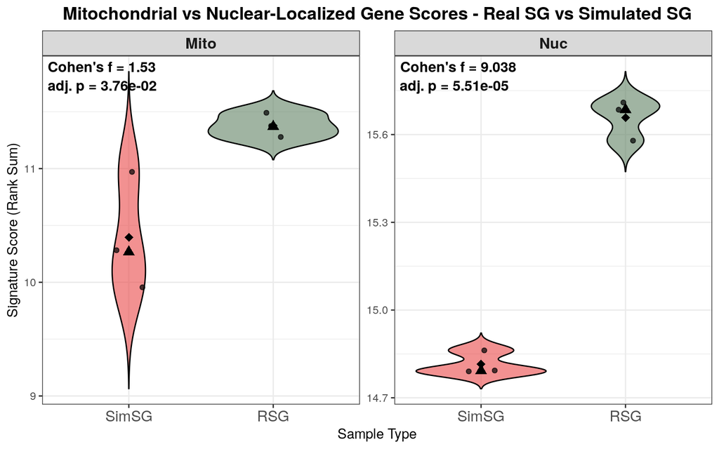

```r
vilsigplot
```

## Volcano Length

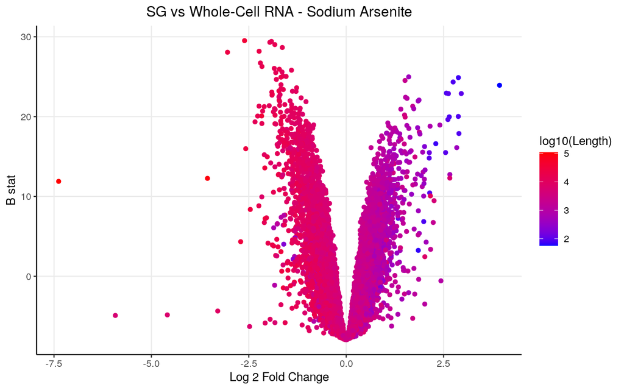

```r
ggplot(data=DEGenes,
                 aes(x=logFC,
                     y=  B)) +
  geom_point(aes(color=log10(Length)))+
  theme_bw() +
  theme(axis.line = element_line(colour = "black"),
        panel.grid.minor = element_blank(),
        panel.border = element_blank(),
        panel.background = element_blank()) +
  ggtitle("SG vs Whole-Cell RNA - Sodium Arsenite")+ ylab("B stat")+xlab("Log 2 Fold Change") +
  theme(plot.title = element_text(hjust = 0.5))  +
  scale_colour_gradient(low = "blue", high = "red")
```

```r
smooth.SG <- lm(t~log10(Length), DEGenes)
liner.SG <- rstandard(smooth.SG)
DEGenes <-cbind(DEGenes, liner.SG)
colnames(DEGenes)[9] <- "Residuals"
row.names(DEGenes) <- DEGenes$Gene

linemarkers <- rbind(upmarkers, downmarkers)
linemarkers <- DEGenes[DEGenes$Gene %in% row.names(linemarkers),]

# Calculate the Spearman correlation coefficient
spearman_corr <- cor(DEGenes$t, log10(DEGenes$Length), method = "spearman")


firstsimcentri <- ggplot(DEGenes, aes(y=t, x=log10(Length))) +
  geom_point(fill = "#DDDDDD", alpha = 0.3, size=5, shape=21, colour='black') +
  geom_density2d(color="#800020", size=1.2)+ theme_bw()+
 xlab("RNA Length (nt)") + ylab("DGE SG-SimSG") +
  theme(axis.line = element_line(colour = "black"),
        panel.grid.minor = element_blank(),
        panel.border = element_blank(),
        panel.background = element_blank()) +
  theme(plot.title = element_text(hjust = 0.5))  +
  geom_abline(slope=smooth.SG$coefficients[2], intercept = smooth.SG$coefficients[1], linetype = "dashed")+ stat_cor(method = "spearman", cor.coef.name = "rho", size=5)+
  theme(text=element_text(size=15,  family="Arial MS")) + stat_cor(method = "spearman", cor.coef.name = "rho", size=5)+ theme(panel.grid.major = element_blank(), panel.grid.minor = element_blank())+
  scale_x_continuous(
    breaks = log10(c(10, 100, 1000, 10000)),  # tick positions (in log10 scale)
    labels = c("10", "100", "1000", "10000") # what you want to show
  )

png("~/Projects/StressGranules/SGPAPER/IadeSim.png", width = 7, height=4, units = "in", res=300)
firstsimcentri
dev.off()
```

## GSEA Enrichment

Now that we have our genes of interest, it would also be interesting to see what are the **altered pathways** between enriched and depleted RNAs from the stress granules. Therefore, lets perform a *Gene Set Enrichment Analysis*

```r
#for all genes
DEGenes <- DEGenes[order(DEGenes[,4]),]
gseatool <- DEGenes[,4]
gseatool <- as.data.frame(gseatool)
colnames(gseatool)[1] <- "t"
gseatool[,2] <- DEGenes$Gene
colnames(gseatool)[2] <- "Symbol"
gseatool <- gseatool[,c(2,1)]

#for only the genes without the contamination


vectorranks <- gseatool$t
names(vectorranks) <- gseatool$Symbol


#to load our pathways
hallmarks.gs <- msigdbr(species = "Homo sapiens", collection = "H")

hallmarks.gsets <- hallmarks.gs %>% split(x = .$gene_symbol, f = .$gs_name)

for (set in names(hallmarks.gsets)){
  hallmarks.gsets[[set]] <- toupper(hallmarks.gsets[[set]])
}

hallmarks.res <- fgsea(pathways = hallmarks.gsets,
                       stats = vectorranks)
```

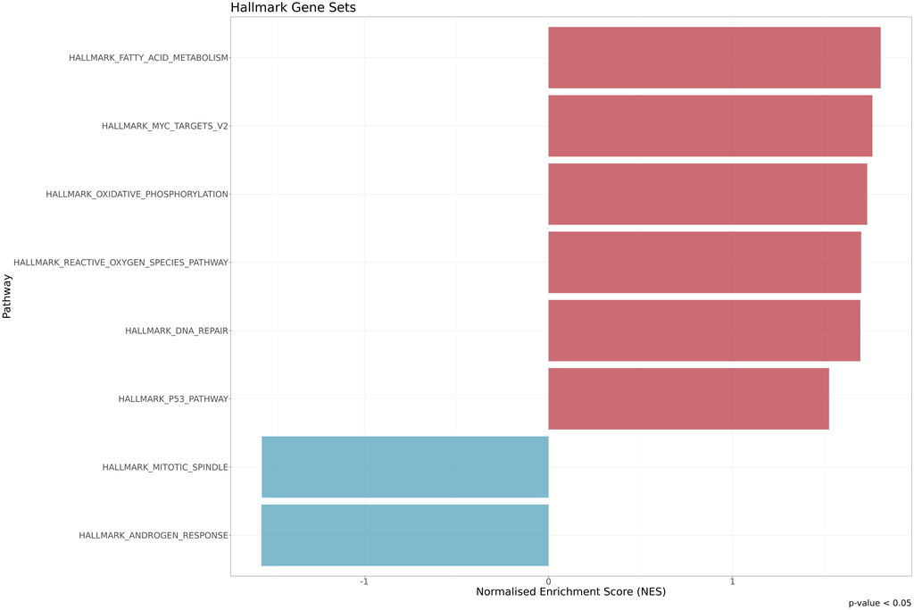

```r
hallmarks.res.tidy <- hallmarks.res %>%
  as_tibble() %>%
  arrange(desc(NES))

hallmarks.res.tidy %>%
  dplyr::select(-leadingEdge, -ES) %>%
  arrange(padj)

hallmark.sg.t <- hallmarks.res.tidy[,c(1,6)]
hallmark.sg.t <- as.data.frame(hallmark.sg.t)

#this small part is generic
thresh <- 0.05

#this one is no longer generic
data_to_plot <- hallmarks.res.tidy %>% filter(padj < thresh)

statvec <- c()
for (i in 1:nrow(data_to_plot)){
  if (data_to_plot[i,6] > 0){
    status <- "Upregulated"
  }
 else {
   status <- "Downregulated"
 }
statvec <- c(statvec, status)
}

data_to_plot$Status <- statvec

##-----HALMARK-----
gsea_plot_hall <- ggplot(data_to_plot, aes(reorder(pathway, NES), NES)) +
  geom_col(aes(fill= Status), alpha=0.75) + scale_fill_manual(values = c("#53A2BE","#BA3B46"), name = "Regulation Status", labels = c("Downregulated", "Upregulated"), breaks = c("Downregulated", "Upregulated")) +
  coord_flip() +
  labs(x="Pathway", y="Normalised Enrichment Score (NES)",
       title= "Hallmark Gene Sets",
       caption = paste0("p-value < ", thresh)) + theme(plot.title = element_text(hjust = 1)) +
  theme_bw() + theme(text=element_text(family = "Quicksand")) + theme(legend.position = "none")


gsea_plot_hall+
  theme(text=element_text(size=25,  family="Arial MS"))
```

### For Mito

```r
# --- Rank genes by t-statistic as usual ---
DEGenes <- DEGenes[order(DEGenes[,4]),]
gseatool <- DEGenes[,4]
gseatool <- as.data.frame(gseatool)
colnames(gseatool)[1] <- "t"
gseatool[,2] <- DEGenes$Gene
colnames(gseatool)[2] <- "Symbol"
gseatool <- gseatool[,c(2,1)]
vectorranks <- gseatool$t
names(vectorranks) <- gseatool$Symbol

# --- Define MitoGenes as a custom gene set ---
MitoGenes <- fread("~/MitoGenes.txt")[[1]]
custom.gsets <- list(MitoGenes = toupper(MitoGenes))

# --- Run fgsea ---
mito.res <- fgsea(pathways = custom.gsets,
                  stats = vectorranks)
```

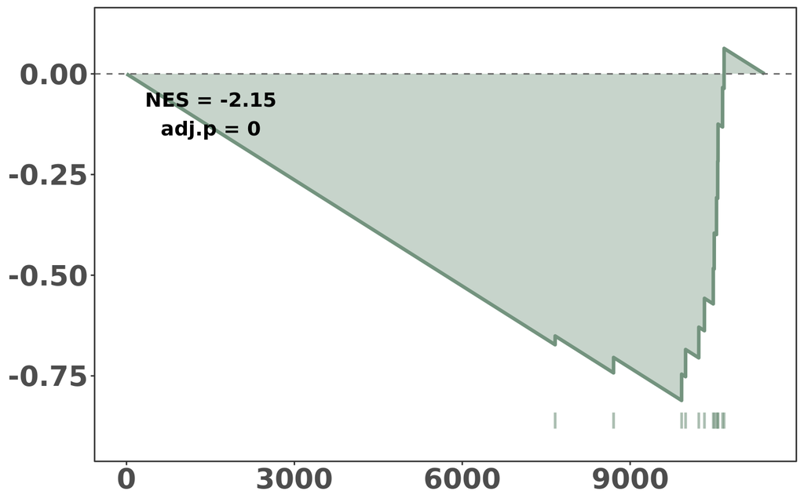

```r
mito.plot.base <- plotEnrichment(custom.gsets[["MitoGenes"]], vectorranks)
curve.data <- mito.plot.base$data

# --- key fix: match the curve's internal descending order ---
ord <- order(vectorranks, decreasing = TRUE)
ranked.names <- names(vectorranks)[ord]
gene.positions <- which(ranked.names %in% custom.gsets[["MitoGenes"]])

rug.top    <- min(curve.data$y) - 0.03
rug.bottom <- rug.top - 0.04

y.min <- rug.bottom - 0.03
y.max <- max(curve.data$y) + 0.05

(mito.plot <- ggplot(curve.data, aes(x = x, y = y)) +
  geom_area(fill = "#73937E", alpha = 0.4) +
  geom_line(color = "#73937E", linewidth = 1.2) +
  geom_hline(yintercept = 0, linetype = "dashed", color = "grey40") +
  geom_segment(data = data.frame(x = gene.positions),
               aes(x = x, xend = x, y = rug.top, yend = rug.bottom),
               color = "#73937E", alpha = 0.6, linewidth = 0.9,
               inherit.aes = FALSE) +
  annotate("text", x = 1500, y = -0.1,
           label = paste0("NES = ", round(mito.res$NES, 2),
                          "\nadj.p = ", round(mito.res$padj, 4)),
           size = 5, family = "Arial MS", fontface = "bold") +
  coord_cartesian(ylim = c(y.min, y.max), clip = "off") +
  theme_bw() +
  theme(text = element_text(size = 25, family = "Arial MS"),
        plot.title = element_text(hjust = 0.5, face = "bold"),
        axis.title = element_blank(),
        axis.text = element_text(face = "bold"),
        panel.grid.minor = element_blank(),
        panel.grid.major = element_blank()))
```

```r
png("~/Projects/StressGranules/SGPAPER/Images/PNG/MitoGSEA_Khong.png", width=7, height=6, units="in", res=300)
mito.plot
dev.off()
```

### For Nuc

```r
# --- Rank genes by t-statistic as usual ---
DEGenes <- DEGenes[order(DEGenes[,4]),]
gseatool <- DEGenes[,4]
gseatool <- as.data.frame(gseatool)
colnames(gseatool)[1] <- "t"
gseatool[,2] <- DEGenes$Gene
colnames(gseatool)[2] <- "Symbol"
gseatool <- gseatool[,c(2,1)]
vectorranks <- gseatool$t
names(vectorranks) <- gseatool$Symbol

# --- Define MitoGenes as a custom gene set ---
MitoGenes <- fread("~/rnalocate_mito_filt.csv")[[1]]
custom.gsets <- list(MitoGenes = toupper(MitoGenes))

# --- Run fgsea ---
mito.res <- fgsea(pathways = custom.gsets,
                  stats = vectorranks)
```

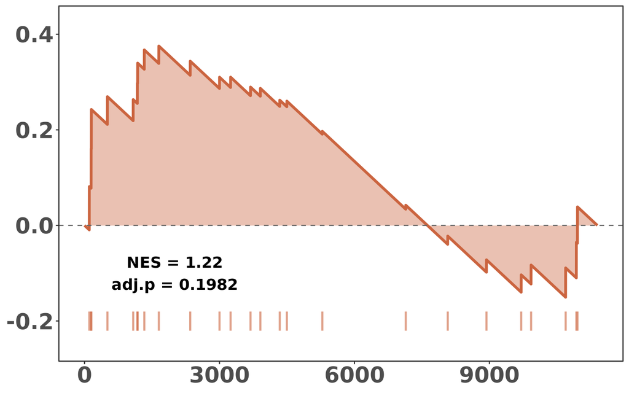

```r
mito.plot.base <- plotEnrichment(custom.gsets[["MitoGenes"]], vectorranks)
curve.data <- mito.plot.base$data

# --- key fix: match the curve's internal descending order ---
ord <- order(vectorranks, decreasing = TRUE)
ranked.names <- names(vectorranks)[ord]
gene.positions <- which(ranked.names %in% custom.gsets[["MitoGenes"]])

rug.top    <- min(curve.data$y) - 0.03
rug.bottom <- rug.top - 0.04

y.min <- rug.bottom - 0.03
y.max <- max(curve.data$y) + 0.05

(mito.plot <- ggplot(curve.data, aes(x = x, y = y)) +
  geom_area(fill = "#CB643F", alpha = 0.4) +
  geom_line(color = "#CB643F", linewidth = 1.2) +
  geom_hline(yintercept = 0, linetype = "dashed", color = "grey40") +
  geom_segment(data = data.frame(x = gene.positions),
               aes(x = x, xend = x, y = rug.top, yend = rug.bottom),
               color = "#CB643F", alpha = 0.6, linewidth = 0.9,
               inherit.aes = FALSE) +
  annotate("text", x = 2000, y = -0.1,
           label = paste0("NES = ", round(mito.res$NES, 2),
                          "\nadj.p = ", round(mito.res$padj, 4)),
           size = 5, family = "Arial MS", fontface = "bold") +
  coord_cartesian(ylim = c(y.min, y.max), clip = "off") +
  theme_bw() +
  theme(text = element_text(size = 25, family = "Arial MS"),
        plot.title = element_text(hjust = 0.5, face = "bold"),
        axis.title = element_blank(),
        axis.text = element_text(face = "bold"),
        panel.grid.minor = element_blank(),
        panel.grid.major = element_blank()))
```

```r
png("~/Projects/StressGranules/SGPAPER/Images/PNG/NucGSEA_Khong.png", width=7, height=6, units="in", res=300)
mito.plot
dev.off()
```

# Comparison Between Original and Simulated Enrichment

Is the SpinSim pipeline, which only takes centrifugation into account, a good recapitulation of DC’s SG enrichment? Here, I directly check this.

```r
cor_sim_df <- merge(simulatedenrichment, originalenrichment, by="Gene")
cor_sim_df <- merge(cor_sim_df, genelength, by="Gene")


smooth.SG <- lm(sim_t ~ og_t, cor_sim_df)
liner.SG <- rstandard(smooth.SG)
cor_sim_df <-cbind(cor_sim_df, liner.SG)
colnames(cor_sim_df)[9] <- "Residuals"
row.names(cor_sim_df) <- cor_sim_df$Gene
linemarkers <- as.data.frame(cor_sim_df[abs(cor_sim_df$Residuals)>4,])

cor.test(cor_sim_df$sim_t, cor_sim_df$og_t, method="spearman")
```

```
##
##  Spearman's rank correlation rho
##
## data:  cor_sim_df$sim_t and cor_sim_df$og_t
## S = 1.1354e+11, p-value < 2.2e-16
## alternative hypothesis: true rho is not equal to 0
## sample estimates:
##       rho
## 0.5400689
```

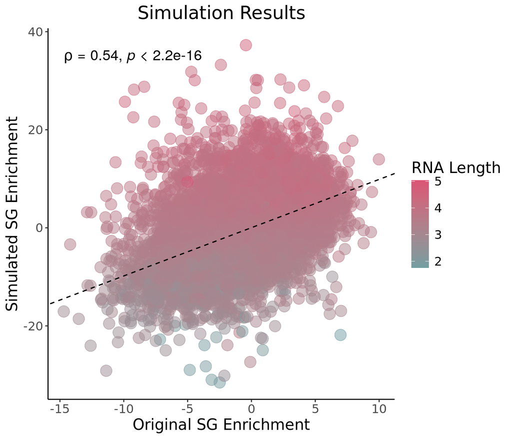

```r
SimCorrel <- ggplot(cor_sim_df, aes(x=og_t, y=sim_t)) + geom_point(aes(colour=log10(Length)),alpha=0.5, size=5) +   theme_bw()+
 xlab("Original SG Enrichment") + ylab("Simulated SG Enrichment") +
  theme(axis.line = element_line(colour = "black"),
        panel.grid.minor = element_blank(),
        panel.border = element_blank(),
        panel.background = element_blank()) + ggtitle("Simulation Results")+
  theme(plot.title = element_text(hjust = 0.5))  +
  geom_abline(slope=smooth.SG$coefficients[2], intercept = smooth.SG$coefficients[1], linetype = "dashed")+
  theme(text=element_text(size=15,  family="Arial MS")) + stat_cor(method = "spearman", cor.coef.name = "rho", size=5) +
  theme(plot.title = element_text(hjust = 0.5)) +
  geom_abline(slope = smooth.SG$coefficients[2],
              intercept = smooth.SG$coefficients[1],
              linetype = "dashed") + theme(panel.grid.major = element_blank(), panel.grid.minor = element_blank())+
  scale_colour_gradient(low="#729EA1", high = "#DB5375")+
  labs(colour = "RNA Length")

SimCorrel
```

```r
#tiff("../Projects/StressGranules/SGPAPER/SimCorrel.tiff", width = 8, height=6, units = "in", res=300)
#SimCorrel
#dev.off()
```

[^1]: Disease Transcriptomics Group, Gulbenkian Institute of Molecular Medicine